# Course Notes on HCI Experiments

Author

Mick McQuaid

Published

July 24, 2026

Following are my course notes from a 2018 Coursera course called *Designing, Running, and Analyzing Experiments*, taught by Jacob Wobbrock, a prominent HCI scholar. Note that Wobbrock is in no way responsible for any errors or deviations from his presentation.

These course notes are an example of *reproducible research* and *literate programming*. They are reproducible research because the same file that generated this html document also ran all the experiments. This is an example of literate programming in the sense that the code, pictures, equations, and narrative are all encapsulated in one file. The source file for this project, along with the data files, are enough for you to reproduce the results and reproduce the documentation. All the source material is available in my github account, although in an obscure location therein.

```r
install.packages("pacman") # install a package manager
pacman::p_load(tidyverse, ggthemes) # use the package manager to install a large bundle of packages, the tidyverse, and another package, ggthemes
options(readr.show_col_types=FALSE) # supress column type messages
```

# How many prefer this over that? (Tests of proportions)

## How many prefer website A over B? (One sample test of proportions in two categories)

Sixty subjects were asked whether they preferred website A or B. Their answer and a subject ID were recorded. Read the data and describe it.

```r
prefsAB <- read_csv("prefsAB.csv")
tail(prefsAB) # displays the last few rows of the data frame
```

```
# A tibble: 6 × 2
  Subject Pref
    <dbl> <chr>
1      55 A
2      56 B
3      57 A
4      58 B
5      59 B
6      60 A
```

```r
prefsAB$Subject <- factor(prefsAB$Subject) # convert to nominal factor
prefsAB$Pref <- factor(prefsAB$Pref) # convert to nominal factor
summary(prefsAB)
```

```
    Subject   Pref
 1      : 1   A:14
 2      : 1   B:46
 3      : 1
 4      : 1
 5      : 1
 6      : 1
 (Other):54
```

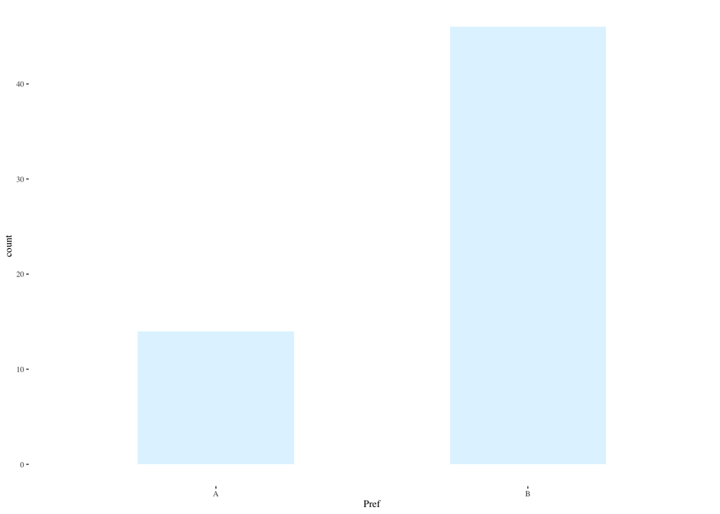

```r
ggplot(prefsAB,aes(Pref)) +
  geom_bar(width=0.5,alpha=0.4,fill="lightskyblue1") +
  theme_tufte(base_size=7)
```

Is the difference between preferences significant? A default $\chi^2$ test examines the proportions in two bins, expecting them to be equally apportioned.

To do the $\chi^2$ test, first crosstabulate the data with `xtabs()`.

```r
#. Pearson chi-square test
prfs <- xtabs( ~ Pref, data=prefsAB)
prfs # show counts
```

```
Pref
 A  B
14 46
```

```r
chisq.test(prfs)
```

```
    Chi-squared test for given probabilities

data:  prfs
X-squared = 17.067, df = 1, p-value = 3.609e-05
```

We don’t really need an exact binomial test yet because the $\chi^2$ test told us enough: that the difference is not likely due to chance. That was only because there are only two choices. If there were more than two, we’d need a binomial test for every pair if the $\chi^2$ test turned up a significant difference. This binomial test just foreshadows what we’ll need when we face three categories.

```r
#. binomial test
#. binom.test(prfs,split.table=Inf)
binom.test(prfs)
```

```
    Exact binomial test

data:  prfs
number of successes = 14, number of trials = 60, p-value = 4.224e-05
alternative hypothesis: true probability of success is not equal to 0.5
95 percent confidence interval:
 0.1338373 0.3603828
sample estimates:
probability of success
             0.2333333
```

## How many prefer website A, B, or C? (One sample test of proportions in three categories)

First, read in and describe the data. Convert Subject to a factor because R reads any numerical data as, well, numeric, but we don’t want to treat it as such. R interprets any data with characters as a factor. We want Subject to be treated as a factor.

```r
prefsABC <- read_csv("prefsABC.csv")
head(prefsABC) # displays the first few rows of the data frame
```

```
# A tibble: 6 × 2
  Subject Pref
    <dbl> <chr>
1       1 C
2       2 C
3       3 B
4       4 C
5       5 C
6       6 B
```

```r
prefsABC$Subject <- factor(prefsABC$Subject)
prefsABC$Pref <- factor(prefsABC$Pref)
summary(prefsABC)
```

```
    Subject   Pref
 1      : 1   A: 8
 2      : 1   B:21
 3      : 1   C:31
 4      : 1
 5      : 1
 6      : 1
 (Other):54
```

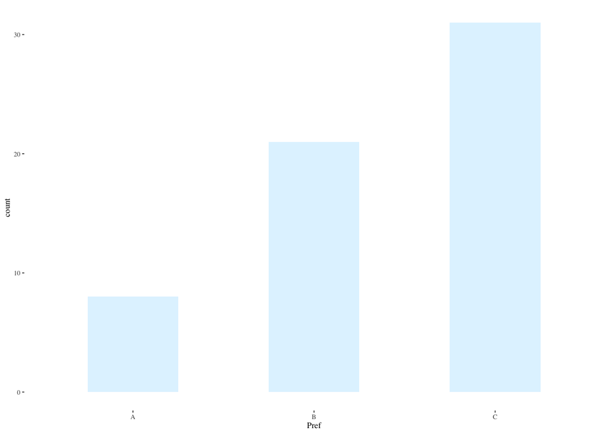

```r
par(pin=c(2.75,1.25),cex=0.5)
ggplot(prefsABC,aes(Pref))+
  geom_bar(width=0.5,alpha=0.4,fill="lightskyblue1")+
  theme_tufte(base_size=7)
```

You can think of the three websites as representing three bins and the preferences as filling up those bins. Either each bin gets one third of the preferences or there is a discrepancy. The Pearson $\chi^2$ test functions as an omnibus test to tell whether there is any discrepancy in the proportions of the three bins.

```r
prfs <- xtabs( ~ Pref, data=prefsABC)
prfs # show counts
```

```
Pref
 A  B  C
 8 21 31
```

```r
chisq.test(prfs)
```

```
    Chi-squared test for given probabilities

data:  prfs
X-squared = 13.3, df = 2, p-value = 0.001294
```

A multinomial test can test for other than an even distribution across bins. Here’s an example with a one third distribution in each bin.

```r
pacman::p_load(XNomial) # install and load a package with the xmulti function
xmulti(prfs, c(1/3, 1/3, 1/3), statName="Prob")
```

```
P value (Prob) = 0.0008024
```

Now we don’t know which pair(s) differed so it makes sense to conduct post hoc binomial tests with correction for multiple comparisons. The correction, made by `p.adjust()`, is because the more hypotheses we check, the higher the probability of a Type I error, a false positive. That is, the more hypotheses we test, the higher the probability that one will appear true by chance. Wikipedia has more detail in its “Multiple Comparisons Problem” article.

Here, we test separately for whether each one has a third of the preferences.

```r
aa <- binom.test(sum(prefsABC$Pref == "A"),
        nrow(prefsABC), p=1/3)
bb <- binom.test(sum(prefsABC$Pref == "B"),
        nrow(prefsABC), p=1/3)
cc <- binom.test(sum(prefsABC$Pref == "C"),
        nrow(prefsABC), p=1/3)
p.adjust(c(aa$p.value, bb$p.value, cc$p.value), method="holm")
```

```
[1] 0.001659954 0.785201685 0.007446980
```

The adjusted $p$-values tell us that A and C differ significantly from a third of the preferences.

## How many males vs females prefer website A over B? (Two-sample tests of proportions in two categories)

Revisit our data file with 2 response categories, but now with sex (M/F).

```r
prefsABsex <- read_csv("prefsABsex.csv")
tail(prefsABsex)
```

```
# A tibble: 6 × 3
  Subject Pref  Sex
    <dbl> <chr> <chr>
1      55 A     M
2      56 B     F
3      57 A     M
4      58 B     M
5      59 B     M
6      60 A     M
```

```r
prefsABsex$Subject <- factor(prefsABsex$Subject)
prefsABsex$Pref <- factor(prefsABsex$Pref)
prefsABsex$Sex <- factor(prefsABsex$Sex)
summary(prefsABsex)
```

```
    Subject   Pref   Sex
 1      : 1   A:14   F:31
 2      : 1   B:46   M:29
 3      : 1
 4      : 1
 5      : 1
 6      : 1
 (Other):54
```

Plotting is slightly more complicated by the fact that we want to represent two groups. There are many ways to do this, including stacked bar charts, side-by-side bars, or the method chosen here, using `facet_wrap(~Sex)` to cause two separate plots based on Sex to be created.

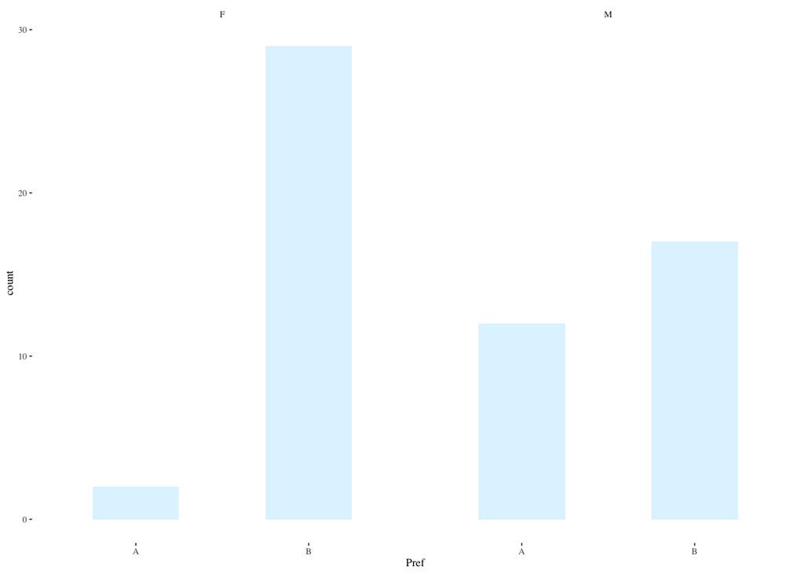

```r
ggplot(prefsABsex,aes(Pref)) +
  geom_bar(width=0.5,alpha=0.4,fill="lightskyblue1") +
  facet_wrap(~Sex) +
  theme_tufte(base_size=7)
```

Although we can guess by looking at the above plot that the difference for females is significant and the difference for males is not, a Pearson chi-square test provides some statistical evidence for this hunch.

```r
prfs <- xtabs( ~ Pref + Sex, data=prefsABsex) # the '+' sign indicates two vars
prfs
```

```
    Sex
Pref  F  M
   A  2 12
   B 29 17
```

```r
chisq.test(prfs)
```

```
    Pearson's Chi-squared test with Yates' continuity correction

data:  prfs
X-squared = 8.3588, df = 1, p-value = 0.003838
```

## What if the data are lopsided? (G-test, alternative to chi-square)

Wikipedia tells us that the $G$-test dominates the $\chi^2$ test when $O_i>2E_i$ in the formula

$$\chi^2=\sum_i \frac{(O_i-E_i)^2}{E_i}$$

where $O_i$ is the observed and $E_i$ is the expected proportion in the $i$th bin. This situation may occur in small sample sizes. For large sample sizes, both tests give the same conclusion. In our case, we’re on the borderline for this rule in the bin where 29 females prefer B. All females would have to prefer B for the rule to dictate a switch to the $G$-test.

```r
pacman::p_load(RVAideMemoire)
G.test(prfs)
```

```
    G-test

data:  prfs
G = 11.025, df = 1, p-value = 0.0008989
```

```r
#. Fisher's exact test
fisher.test(prfs)
```

```
    Fisher's Exact Test for Count Data

data:  prfs
p-value = 0.001877
alternative hypothesis: true odds ratio is not equal to 1
95 percent confidence interval:
 0.009898352 0.537050159
sample estimates:
odds ratio
 0.1015763
```

## How many males vs females prefer website A, B, or C? (Two-sample tests of proportions in three categories)

Revisit our data file with 3 response categories, but now with sex (M/F).

```r
prefsABCsex <- read_csv("prefsABCsex.csv")
head(prefsABCsex)
```

```
# A tibble: 6 × 3
  Subject Pref  Sex
    <dbl> <chr> <chr>
1       1 C     F
2       2 C     M
3       3 B     M
4       4 C     M
5       5 C     M
6       6 B     F
```

```r
prefsABCsex$Subject <- factor(prefsABCsex$Subject)
prefsABCsex$Pref <- factor(prefsABCsex$Pref)
prefsABCsex$Sex <- factor(prefsABCsex$Sex)
summary(prefsABCsex)
```

```
    Subject   Pref   Sex
 1      : 1   A: 8   F:29
 2      : 1   B:21   M:31
 3      : 1   C:31
 4      : 1
 5      : 1
 6      : 1
 (Other):54
```

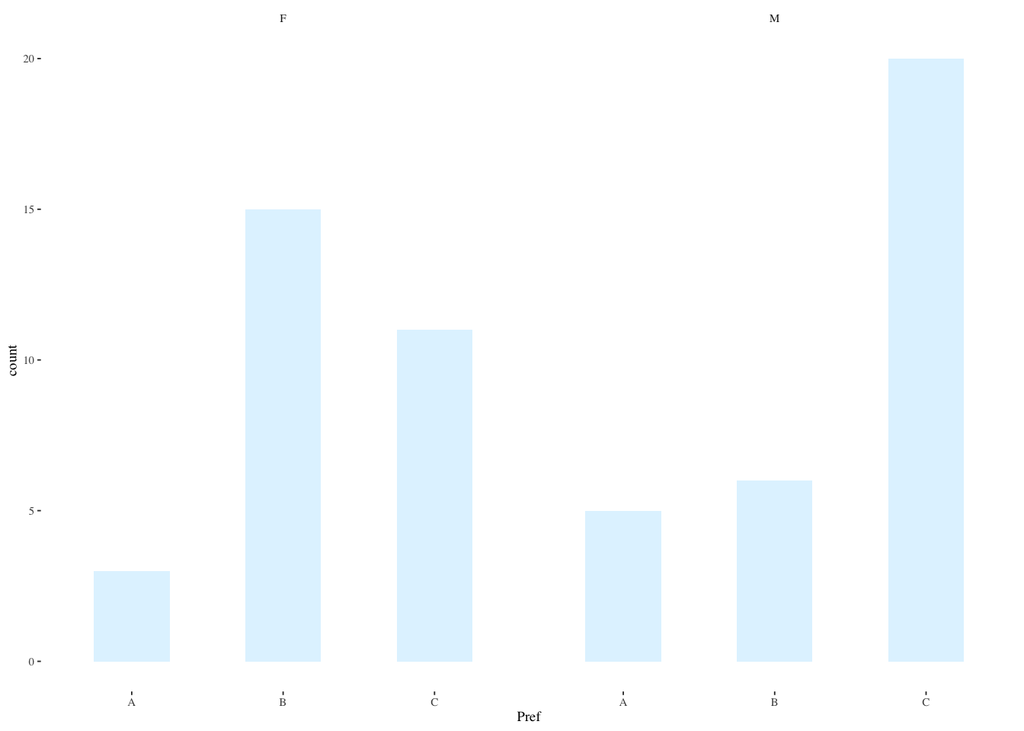

```r
ggplot(prefsABCsex,aes(Pref)) +
  geom_bar(width=0.5,alpha=0.4,fill="lightskyblue1") +
  facet_wrap(~Sex) +
  theme_tufte(base_size=7)
```

```r
#. Pearson chi-square test
prfs <- xtabs( ~ Pref + Sex, data=prefsABCsex)
prfs
```

```
    Sex
Pref  F  M
   A  3  5
   B 15  6
   C 11 20
```

```r
chisq.test(prfs)
```

```
    Pearson's Chi-squared test

data:  prfs
X-squared = 6.9111, df = 2, p-value = 0.03157
```

```r
#. G-test
G.test(prfs)
```

```
    G-test

data:  prfs
G = 7.0744, df = 2, p-value = 0.02909
```

```r
#. Fisher's exact test
fisher.test(prfs)
```

```
    Fisher's Exact Test for Count Data

data:  prfs
p-value = 0.03261
alternative hypothesis: two.sided
```

Now conduct manual post hoc binomial tests for (m)ales—do any prefs for A–C significantly differ from chance for males?

```r
ma <- binom.test(sum(prefsABCsex[prefsABCsex$Sex == "M",]$Pref == "A"),
        nrow(prefsABCsex[prefsABCsex$Sex == "M",]), p=1/3)
mb <- binom.test(sum(prefsABCsex[prefsABCsex$Sex == "M",]$Pref == "B"),
        nrow(prefsABCsex[prefsABCsex$Sex == "M",]), p=1/3)
mc <- binom.test(sum(prefsABCsex[prefsABCsex$Sex == "M",]$Pref == "C"),
        nrow(prefsABCsex[prefsABCsex$Sex == "M",]), p=1/3)
#. correct for multiple comparisons
p.adjust(c(ma$p.value, mb$p.value, mc$p.value), method="holm")
```

```
[1] 0.109473564 0.126622172 0.001296754
```

Next, conduct manual post hoc binomial tests for (f)emales—do any prefs for A–C significantly differ from chance for females?

```r
fa <- binom.test(sum(prefsABCsex[prefsABCsex$Sex == "F",]$Pref == "A"),
        nrow(prefsABCsex[prefsABCsex$Sex == "F",]), p=1/3)
fb <- binom.test(sum(prefsABCsex[prefsABCsex$Sex == "F",]$Pref == "B"),
        nrow(prefsABCsex[prefsABCsex$Sex == "F",]), p=1/3)
fc <- binom.test(sum(prefsABCsex[prefsABCsex$Sex == "F",]$Pref == "C"),
        nrow(prefsABCsex[prefsABCsex$Sex == "F",]), p=1/3)
#. correct for multiple comparisons
p.adjust(c(fa$p.value, fb$p.value, fc$p.value), method="holm")
```

```
[1] 0.02703274 0.09447821 0.69396951
```

# How do groups compare in reading performance? (Independent samples $t$-test)

Here we are asking which group read more pages on a particular website.

```r
pgviews <- read_csv("pgviews.csv")
pgviews$Subject <- factor(pgviews$Subject)
pgviews$Site <- factor(pgviews$Site)
summary(pgviews)
```

```
    Subject    Site        Pages
 1      :  1   A:245   Min.   : 1.000
 2      :  1   B:255   1st Qu.: 3.000
 3      :  1           Median : 4.000
 4      :  1           Mean   : 3.958
 5      :  1           3rd Qu.: 5.000
 6      :  1           Max.   :11.000
 (Other):494
```

```r
tail(pgviews)
```

```
# A tibble: 6 × 3
  Subject Site  Pages
  <fct>   <fct> <dbl>
1 495     A         3
2 496     B         6
3 497     B         6
4 498     A         3
5 499     A         4
6 500     B         6
```

```r
#. descriptive statistics by Site
pacman::p_load(plyr)
plyr::ddply(pgviews, ~ Site, function(data) summary(data$Pages))
```

```
  Site Min. 1st Qu. Median     Mean 3rd Qu. Max.
1    A    1       3      3 3.404082       4    6
2    B    1       3      4 4.490196       6   11
```

```r
plyr::ddply(pgviews, ~ Site, summarise, Pages.mean=mean(Pages), Pages.sd=sd(Pages))
```

```
  Site Pages.mean Pages.sd
1    A   3.404082 1.038197
2    B   4.490196 2.127552
```

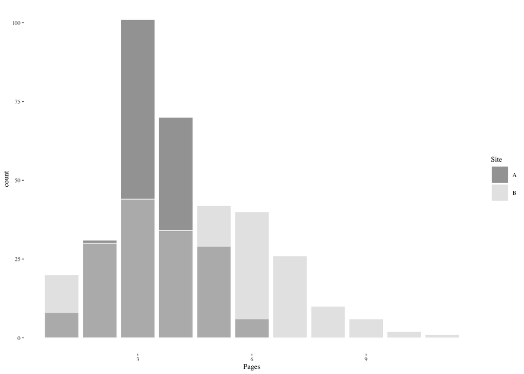

```r
#. graph histograms and a boxplot
ggplot(pgviews,aes(Pages,fill=Site,color=Site)) +
  geom_bar(alpha=0.5,position="identity",color="white") +
  scale_color_grey() +
  scale_fill_grey() +
  theme_tufte(base_size=7)
```

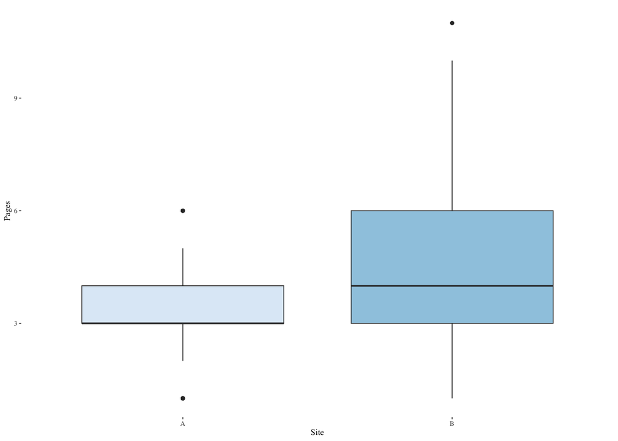

```r
ggplot(pgviews,aes(Site,Pages,fill=Site)) +
  geom_boxplot(show.legend=FALSE) +
  scale_fill_brewer(palette="Blues") +
  theme_tufte(base_size=7)
```

```r
#. independent-samples t-test
t.test(Pages ~ Site, data=pgviews, var.equal=TRUE)
```

```
    Two Sample t-test

data:  Pages by Site
t = -7.2083, df = 498, p-value = 2.115e-12
alternative hypothesis: true difference in means between group A and group B is not equal to 0
95 percent confidence interval:
 -1.3821544 -0.7900745
sample estimates:
mean in group A mean in group B
       3.404082        4.490196
```

# ANOVA

ANOVA stands for analysis of variance and is a way to generalize the $t$-test to more groups.

## How long does it take to perform tasks on two IDEs?

```r
ide2 <- read_csv("ide2.csv")
ide2$Subject <- factor(ide2$Subject) # convert to nominal factor
ide2$IDE <- factor(ide2$IDE) # convert to nominal factor
summary(ide2)
```

```
    Subject        IDE          Time
 1      : 1   Eclipse:20   Min.   :155.0
 2      : 1   VStudio:20   1st Qu.:271.8
 3      : 1                Median :313.5
 4      : 1                Mean   :385.1
 5      : 1                3rd Qu.:422.0
 6      : 1                Max.   :952.0
 (Other):34
```

```r
#. view descriptive statistics by IDE
plyr::ddply(ide2, ~ IDE, function(data) summary(data$Time))
```

```
      IDE Min. 1st Qu. Median   Mean 3rd Qu. Max.
1 Eclipse  232  294.75  393.5 468.15  585.50  952
2 VStudio  155  246.50  287.0 302.10  335.25  632
```

```r
plyr::ddply(ide2, ~ IDE, summarise, Time.mean=mean(Time), Time.sd=sd(Time))
```

```
      IDE Time.mean  Time.sd
1 Eclipse    468.15 218.1241
2 VStudio    302.10 101.0778
```

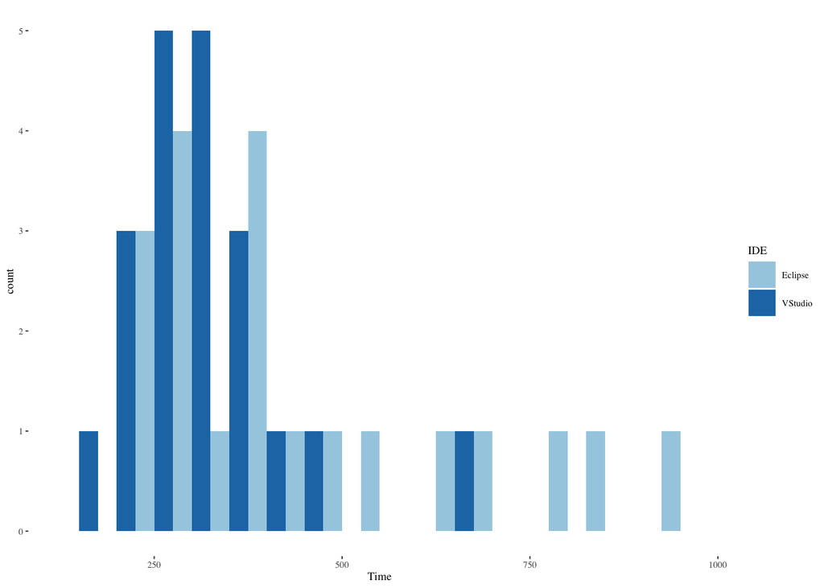

```r
#. graph histograms and a boxplot
ggplot(ide2,aes(Time,fill=IDE)) +
  geom_histogram(binwidth=50,position=position_dodge()) +
  scale_fill_brewer(palette="Paired") +
  theme_tufte(base_size=7)
```

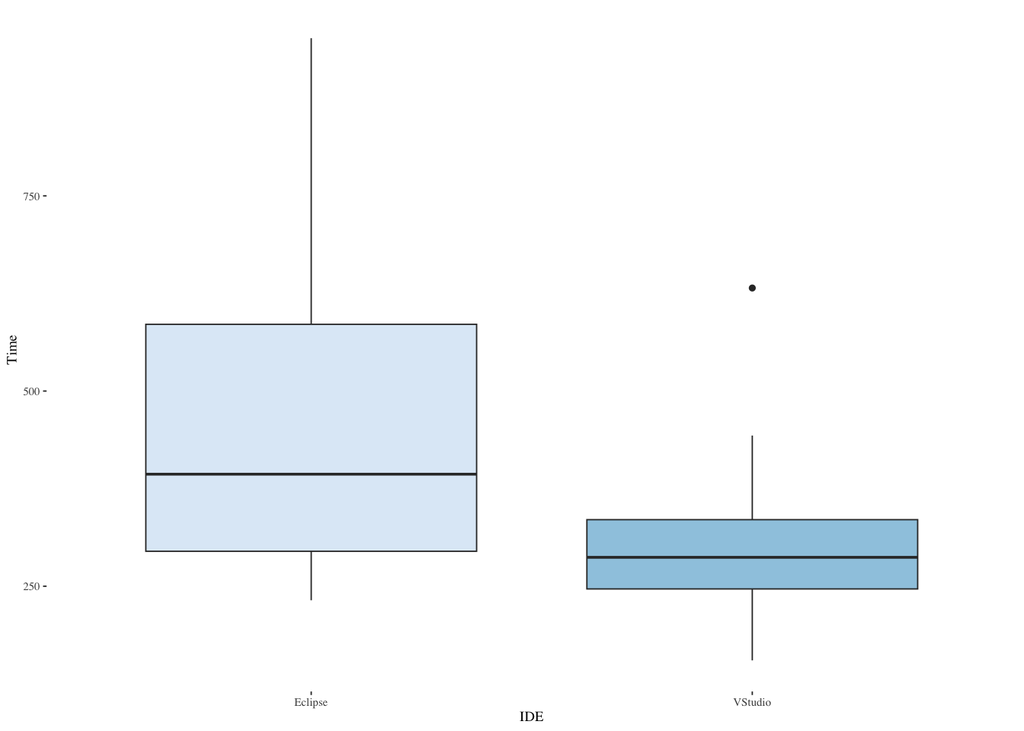

```r
ggplot(ide2,aes(IDE,Time,fill=IDE)) +
  geom_boxplot(show.legend=FALSE) +
  scale_fill_brewer(palette="Blues") +
  theme_tufte(base_size=7)
```

```r
#. independent-samples t-test (suitable? maybe not, because...)
t.test(Time ~ IDE, data=ide2, var.equal=TRUE)
```

```
    Two Sample t-test

data:  Time by IDE
t = 3.0889, df = 38, p-value = 0.003745
alternative hypothesis: true difference in means between group Eclipse and group VStudio is not equal to 0
95 percent confidence interval:
  57.226 274.874
sample estimates:
mean in group Eclipse mean in group VStudio
               468.15                302.10
```

## Testing ANOVA assumptions

```r
#. Shapiro-Wilk normality test on response
shapiro.test(ide2[ide2$IDE == "VStudio",]$Time)
```

```
    Shapiro-Wilk normality test

data:  ide2[ide2$IDE == "VStudio", ]$Time
W = 0.84372, p-value = 0.004191
```

```r
shapiro.test(ide2[ide2$IDE == "Eclipse",]$Time)
```

```
    Shapiro-Wilk normality test

data:  ide2[ide2$IDE == "Eclipse", ]$Time
W = 0.87213, p-value = 0.01281
```

```r
#. but really what matters most is the residuals
m = aov(Time ~ IDE, data=ide2) # fit model
shapiro.test(residuals(m)) # test residuals
```

```
    Shapiro-Wilk normality test

data:  residuals(m)
W = 0.894, p-value = 0.001285
```

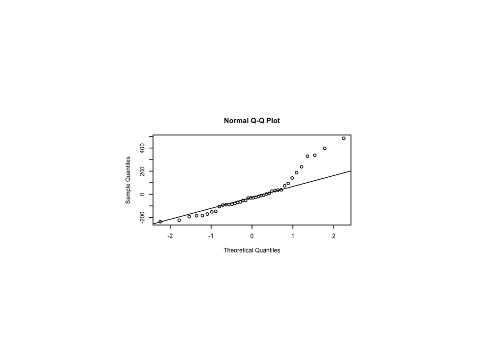

```r
par(pin=c(2.75,1.25),cex=0.5)
qqnorm(residuals(m)); qqline(residuals(m)) # plot residuals
```

## Kolmogorov-Smirnov test for log-normality

Fit the distribution to a lognormal to estimate fit parameters then supply those to a K-S test with the lognormal distribution fn (see ?plnorm). See ?distributions for many other named probability distributions.

```r
pacman::p_load(MASS)
fit <- fitdistr(ide2[ide2$IDE == "VStudio",]$Time,
           "lognormal")$estimate
ks.test(ide2[ide2$IDE == "VStudio",]$Time, "plnorm",
    meanlog=fit[1], sdlog=fit[2], exact=TRUE)
```

```
    Exact one-sample Kolmogorov-Smirnov test

data:  ide2[ide2$IDE == "VStudio", ]$Time
D = 0.13421, p-value = 0.8181
alternative hypothesis: two-sided
```

```r
fit <- fitdistr(ide2[ide2$IDE == "Eclipse",]$Time,
           "lognormal")$estimate
ks.test(ide2[ide2$IDE == "Eclipse",]$Time, "plnorm",
    meanlog=fit[1], sdlog=fit[2], exact=TRUE)
```

```
    Exact one-sample Kolmogorov-Smirnov test

data:  ide2[ide2$IDE == "Eclipse", ]$Time
D = 0.12583, p-value = 0.871
alternative hypothesis: two-sided
```

```r
#. tests for homoscedasticity (homogeneity of variance)
pacman::p_load(car)
leveneTest(Time ~ IDE, data=ide2, center=mean) # Levene's test
```

```
Levene's Test for Homogeneity of Variance (center = mean)
      Df F value   Pr(>F)
group  1  11.959 0.001356 **
      38
---
Signif. codes:  0 '***' 0.001 '**' 0.01 '*' 0.05 '.' 0.1 ' ' 1
```

```r
leveneTest(Time ~ IDE, data=ide2, center=median) # Brown-Forsythe test
```

```
Levene's Test for Homogeneity of Variance (center = median)
      Df F value  Pr(>F)
group  1  5.9144 0.01984 *
      38
---
Signif. codes:  0 '***' 0.001 '**' 0.01 '*' 0.05 '.' 0.1 ' ' 1
```

```r
#. Welch t-test for unequal variances handles
#. the violation of homoscedasticity. but not
#. the violation of normality.
t.test(Time ~ IDE, data=ide2, var.equal=FALSE) # Welch t-test
```

```
    Welch Two Sample t-test

data:  Time by IDE
t = 3.0889, df = 26.8, p-value = 0.004639
alternative hypothesis: true difference in means between group Eclipse and group VStudio is not equal to 0
95 percent confidence interval:
  55.71265 276.38735
sample estimates:
mean in group Eclipse mean in group VStudio
               468.15                302.10
```

## Data transformation

```r
#. create a new column in ide2 defined as log(Time)
ide2$logTime <- log(ide2$Time) # log transform
head(ide2) # verify
```

```
# A tibble: 6 × 4
  Subject IDE      Time logTime
  <fct>   <fct>   <dbl>   <dbl>
1 1       VStudio   341    5.83
2 2       VStudio   291    5.67
3 3       VStudio   283    5.65
4 4       VStudio   155    5.04
5 5       VStudio   271    5.60
6 6       VStudio   270    5.60
```

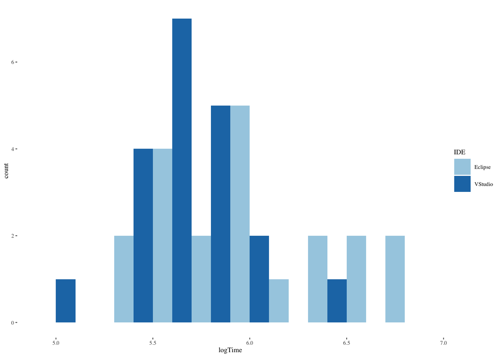

```r
#. explore for intuition-building
ggplot(ide2,aes(logTime,fill=IDE)) +
  geom_histogram(binwidth=0.2,position=position_dodge()) +
  scale_fill_brewer(palette="Paired") +
  theme_tufte(base_size=7)
```

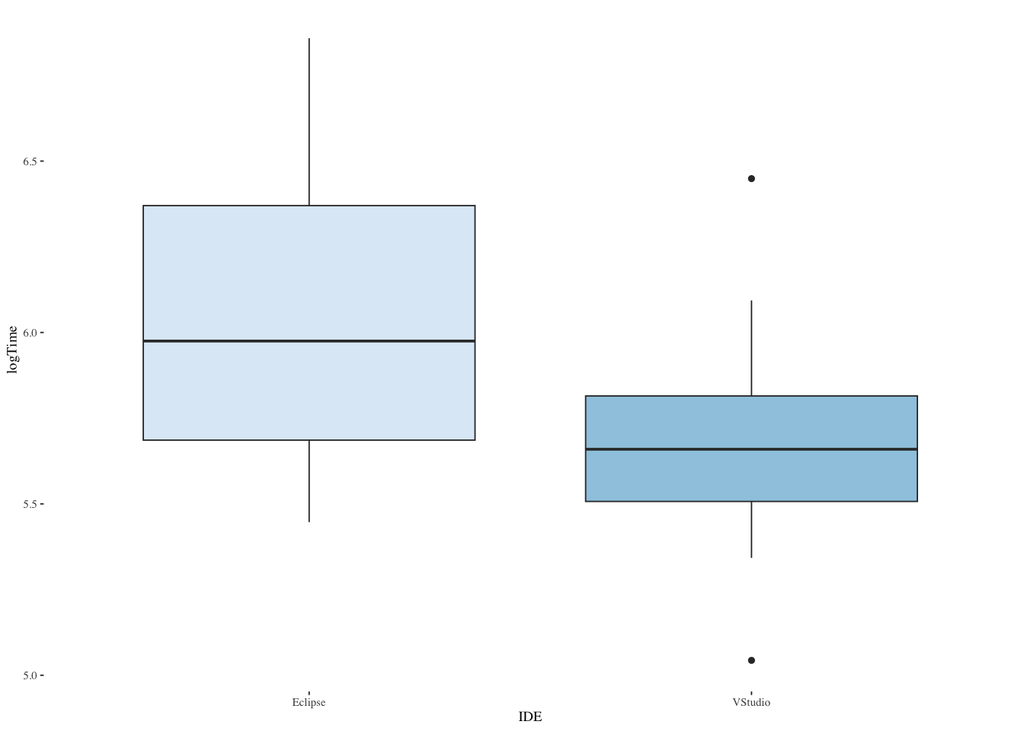

```r
ggplot(ide2,aes(IDE,logTime,fill=IDE)) +
  geom_boxplot(show.legend=FALSE) +
  scale_fill_brewer(palette="Blues") +
  theme_tufte(base_size=7)
```

```r
#. re-test for normality
shapiro.test(ide2[ide2$IDE == "VStudio",]$logTime)
```

```
    Shapiro-Wilk normality test

data:  ide2[ide2$IDE == "VStudio", ]$logTime
W = 0.95825, p-value = 0.5094
```

```r
shapiro.test(ide2[ide2$IDE == "Eclipse",]$logTime)
```

```
    Shapiro-Wilk normality test

data:  ide2[ide2$IDE == "Eclipse", ]$logTime
W = 0.93905, p-value = 0.23
```

```r
m <- aov(logTime ~ IDE, data=ide2) # fit model
shapiro.test(residuals(m)) # test residuals
```

```
    Shapiro-Wilk normality test

data:  residuals(m)
W = 0.96218, p-value = 0.1987
```

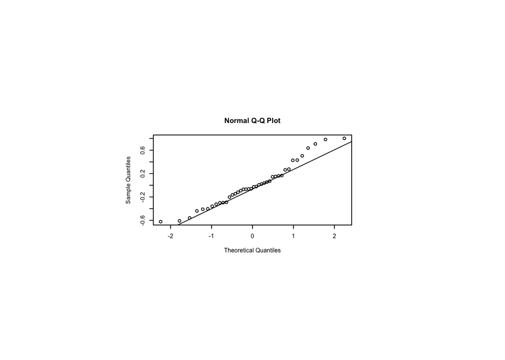

```r
par(pin=c(2.75,1.25),cex=0.5)
qqnorm(residuals(m)); qqline(residuals(m)) # plot residuals
```

```r
#. re-test for homoscedasticity
leveneTest(logTime ~ IDE, data=ide2, center=median) # Brown-Forsythe test
```

```
Levene's Test for Homogeneity of Variance (center = median)
      Df F value  Pr(>F)
group  1  3.2638 0.07875 .
      38
---
Signif. codes:  0 '***' 0.001 '**' 0.01 '*' 0.05 '.' 0.1 ' ' 1
```

```r
#. independent-samples t-test (now suitable for logTime)
t.test(logTime ~ IDE, data=ide2, var.equal=TRUE)
```

```
    Two Sample t-test

data:  logTime by IDE
t = 3.3121, df = 38, p-value = 0.002039
alternative hypothesis: true difference in means between group Eclipse and group VStudio is not equal to 0
95 percent confidence interval:
 0.1514416 0.6276133
sample estimates:
mean in group Eclipse mean in group VStudio
             6.055645              5.666118
```

## What if ANOVA assumptions don’t hold? (Nonparametric equivalent of independent-samples t-test)

## Mann-Whitney U test

```r
pacman::p_load(coin)
wilcox_test(Time ~ IDE, data=ide2, distribution="exact")
```

```
    Exact Wilcoxon-Mann-Whitney Test

data:  Time by IDE (Eclipse, VStudio)
Z = 2.9487, p-value = 0.002577
alternative hypothesis: true mu is not equal to 0
```

```r
wilcox_test(logTime ~ IDE, data=ide2, distribution="exact") # note: same result
```

```
    Exact Wilcoxon-Mann-Whitney Test

data:  logTime by IDE (Eclipse, VStudio)
Z = 2.9487, p-value = 0.002577
alternative hypothesis: true mu is not equal to 0
```

## How long does it take to do tasks on one of three tools? (One-way ANOVA preparation)

```r
#. read in a data file with task completion times (min) now from 3 tools
ide3 <- read_csv("ide3.csv")
ide3$Subject <- factor(ide3$Subject) # convert to nominal factor
ide3$IDE <- factor(ide3$IDE) # convert to nominal factor
summary(ide3)
```

```
    Subject        IDE          Time
 1      : 1   Eclipse:20   Min.   :143.0
 2      : 1   PyCharm:20   1st Qu.:248.8
 3      : 1   VStudio:20   Median :295.0
 4      : 1                Mean   :353.9
 5      : 1                3rd Qu.:391.2
 6      : 1                Max.   :952.0
 (Other):54
```

```r
#. view descriptive statistics by IDE
plyr::ddply(ide3, ~ IDE, function(data) summary(data$Time))
```

```
      IDE Min. 1st Qu. Median   Mean 3rd Qu. Max.
1 Eclipse  232  294.75  393.5 468.15  585.50  952
2 PyCharm  143  232.25  279.5 291.45  300.00  572
3 VStudio  155  246.50  287.0 302.10  335.25  632
```

```r
plyr::ddply(ide3, ~ IDE, summarise, Time.mean=mean(Time), Time.sd=sd(Time))
```

```
      IDE Time.mean  Time.sd
1 Eclipse    468.15 218.1241
2 PyCharm    291.45 106.8922
3 VStudio    302.10 101.0778
```

```r
ide3 |>
  group_by(IDE) |>
  summarize(median=median(Time),mean=mean(Time),sd=sd(Time))
```

```
  median  mean       sd
1    295 353.9 170.1406
```

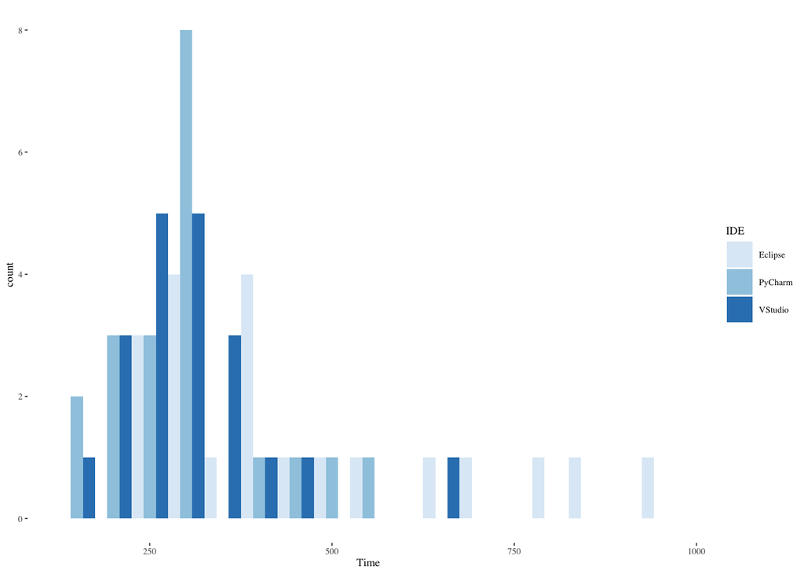

```r
#. explore new response distribution
ggplot(ide3,aes(Time,fill=IDE)) +
  geom_histogram(binwidth=50,position=position_dodge()) +
  scale_fill_brewer(palette="Blues") +
  theme_tufte(base_size=7)
```

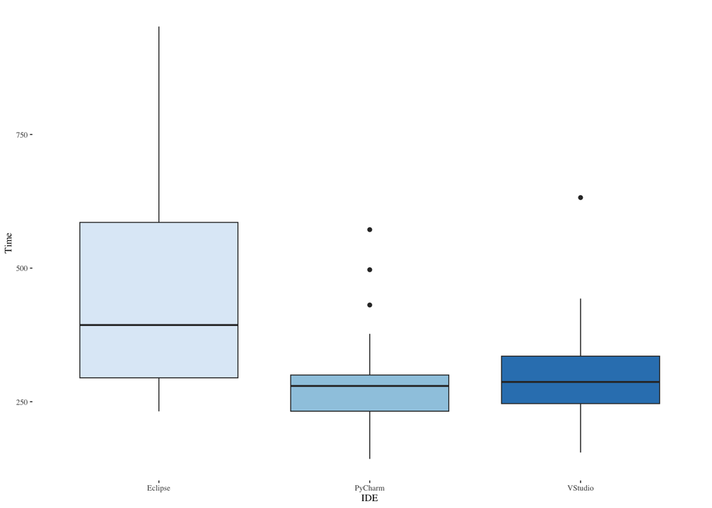

```r
ggplot(ide3,aes(IDE,Time,fill=IDE)) +
  geom_boxplot(show.legend=FALSE) +
  scale_fill_brewer(palette="Blues") +
  theme_tufte(base_size=7)
```

```r
#. test normality for new IDE
shapiro.test(ide3[ide3$IDE == "PyCharm",]$Time)
```

```
    Shapiro-Wilk normality test

data:  ide3[ide3$IDE == "PyCharm", ]$Time
W = 0.88623, p-value = 0.02294
```

```r
m <- aov(Time ~ IDE, data=ide3) # fit model
shapiro.test(residuals(m)) # test residuals
```

```
    Shapiro-Wilk normality test

data:  residuals(m)
W = 0.89706, p-value = 0.000103
```

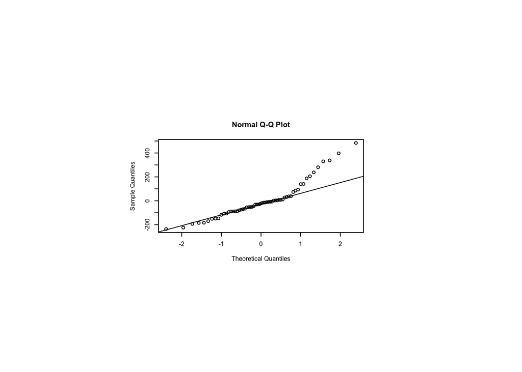

```r
par(pin=c(2.75,1.25),cex=0.5)
qqnorm(residuals(m)); qqline(residuals(m)) # plot residuals
```

```r
#. test log-normality of new IDE
fit <- fitdistr(ide3[ide3$IDE == "PyCharm",]$Time, "lognormal")$estimate
ks.test(ide3[ide3$IDE == "PyCharm",]$Time,
    "plnorm", meanlog=fit[1], sdlog=fit[2], exact=TRUE) # lognormality
```

```
    Exact one-sample Kolmogorov-Smirnov test

data:  ide3[ide3$IDE == "PyCharm", ]$Time
D = 0.1864, p-value = 0.4377
alternative hypothesis: two-sided
```

```r
#. compute new log(Time) column and re-test
ide3$logTime <- log(ide3$Time) # add new column
shapiro.test(ide3[ide3$IDE == "PyCharm",]$logTime)
```

```
    Shapiro-Wilk normality test

data:  ide3[ide3$IDE == "PyCharm", ]$logTime
W = 0.96579, p-value = 0.6648
```

```r
m <- aov(logTime ~ IDE, data=ide3) # fit model
shapiro.test(residuals(m)) # test residuals
```

```
    Shapiro-Wilk normality test

data:  residuals(m)
W = 0.96563, p-value = 0.08893
```

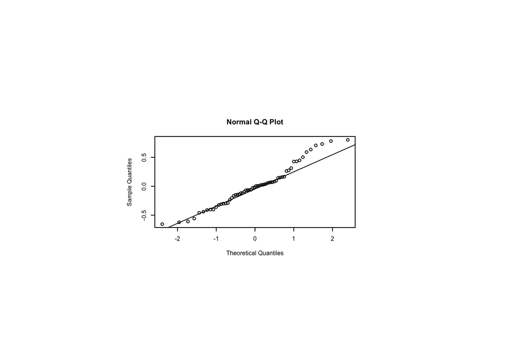

```r
par(pin=c(2.75,1.25),cex=0.5)
qqnorm(residuals(m)); qqline(residuals(m)) # plot residuals
```

```r
#. test homoscedasticity
leveneTest(logTime ~ IDE, data=ide3, center=median) # Brown-Forsythe test
```

```
Levene's Test for Homogeneity of Variance (center = median)
      Df F value Pr(>F)
group  2  1.7797 0.1779
      57
```

## Can we transform data so it fits assumptions? (One-way ANOVA, suitable now to logTime)

```r
m <- aov(logTime ~ IDE, data=ide3) # fit model
anova(m) # report anova
```

```
Analysis of Variance Table

Response: logTime
          Df Sum Sq Mean Sq F value    Pr(>F)
IDE        2 2.3064  1.1532   8.796 0.0004685 ***
Residuals 57 7.4729  0.1311
---
Signif. codes:  0 '***' 0.001 '**' 0.01 '*' 0.05 '.' 0.1 ' ' 1
```

```r
#. post hoc independent-samples t-tests
pacman::p_load(multcomp)
summary(glht(m, mcp(IDE="Tukey")), test=adjusted(type="holm")) # Tukey means compare all pairs
```

```
     Simultaneous Tests for General Linear Hypotheses

Multiple Comparisons of Means: Tukey Contrasts


Fit: aov(formula = logTime ~ IDE, data = ide3)

Linear Hypotheses:
                       Estimate Std. Error t value Pr(>|t|)
PyCharm - Eclipse == 0  -0.4380     0.1145  -3.826 0.000978 ***
VStudio - Eclipse == 0  -0.3895     0.1145  -3.402 0.002458 **
VStudio - PyCharm == 0   0.0485     0.1145   0.424 0.673438
---
Signif. codes:  0 '***' 0.001 '**' 0.01 '*' 0.05 '.' 0.1 ' ' 1
(Adjusted p values reported -- holm method)
```

```r
#. note: equivalent to this using lsm instead of mcp
pacman::p_load(emmeans)
summary(glht(m, lsm(pairwise ~ IDE)), test=adjusted(type="holm"))
```

```
     Simultaneous Tests for General Linear Hypotheses

Fit: aov(formula = logTime ~ IDE, data = ide3)

Linear Hypotheses:
                       Estimate Std. Error t value Pr(>|t|)
Eclipse - PyCharm == 0   0.4380     0.1145   3.826 0.000978 ***
Eclipse - VStudio == 0   0.3895     0.1145   3.402 0.002458 **
PyCharm - VStudio == 0  -0.0485     0.1145  -0.424 0.673438
---
Signif. codes:  0 '***' 0.001 '**' 0.01 '*' 0.05 '.' 0.1 ' ' 1
(Adjusted p values reported -- holm method)
```

## What if we can’t transform data to fit ANOVA assumptions? (Nonparametric equivalent of one-way ANOVA)

```r
#. Kruskal-Wallis test
kruskal_test(Time ~ IDE, data=ide3, distribution="asymptotic") # can't do exact with 3 levels
```

```
    Asymptotic Kruskal-Wallis Test

data:  Time by IDE (Eclipse, PyCharm, VStudio)
chi-squared = 12.17, df = 2, p-value = 0.002277
```

```r
kruskal_test(logTime ~ IDE, data=ide3, distribution="asymptotic") # note: same result
```

```
    Asymptotic Kruskal-Wallis Test

data:  logTime by IDE (Eclipse, PyCharm, VStudio)
chi-squared = 12.17, df = 2, p-value = 0.002277
```

```r
#. for reporting Kruskal-Wallis as chi-square, we can get N with nrow(ide3)

#. manual post hoc Mann-Whitney U pairwise comparisons
#. note: wilcox_test we used above doesn't take two data vectors, so use wilcox.test
vs.ec <- wilcox.test(ide3[ide3$IDE == "VStudio",]$Time,
            ide3[ide3$IDE == "Eclipse",]$Time, exact=FALSE)
vs.py <- wilcox.test(ide3[ide3$IDE == "VStudio",]$Time,
            ide3[ide3$IDE == "PyCharm",]$Time, exact=FALSE)
ec.py <- wilcox.test(ide3[ide3$IDE == "Eclipse",]$Time,
            ide3[ide3$IDE == "PyCharm",]$Time, exact=FALSE)
p.adjust(c(vs.ec$p.value, vs.py$p.value, ec.py$p.value), method="holm")
```

```
[1] 0.007681846 0.588488864 0.007681846
```

```r
#. alternative approach is using PMCMRplus for nonparam pairwise comparisons
pacman::p_load(PMCMRplus)
kwAllPairsConoverTest(Time ~ IDE, data=ide3, p.adjust.method="holm")
```

```
    Pairwise comparisons using Conover's all-pairs test
```

```
data: Time by IDE
```

```
        Eclipse PyCharm
PyCharm 0.0025  -
VStudio 0.0062  0.6620
```

```
P value adjustment method: holm
```

The above test was reported by W. J. Conover and R. L. Iman (1979), *On multiple-comparisons procedures*, Tech. Rep. LA-7677-MS, Los Alamos Scientific Laboratory.

# Another example of tasks using two tools (More on oneway ANOVA)

The `designtime` data records task times in minutes to complete the same project in Illustrator or InDesign.

Read the designtime data into R. Determine how many subjects participated.

```r
dt<-read_csv("designtime.csv")
#. convert Subject to a factor
dt$Subject<-as.factor(dt$Subject)
dt$Tool<-as.factor(dt$Tool)
summary(dt)
```

```
    Subject            Tool         Time
 1      : 1   Illustrator:30   Min.   : 98.19
 2      : 1   InDesign   :30   1st Qu.:149.34
 3      : 1                    Median :205.54
 4      : 1                    Mean   :275.41
 5      : 1                    3rd Qu.:361.99
 6      : 1                    Max.   :926.15
 (Other):54
```

```r
length(dt$Subject)
```

```
[1] 60
```

```r
tail(dt)
```

```
# A tibble: 6 × 3
  Subject Tool         Time
  <fct>   <fct>       <dbl>
1 55      Illustrator  218.
2 56      InDesign     180.
3 57      Illustrator  170.
4 58      InDesign     186.
5 59      Illustrator  241.
6 60      InDesign     159.
```

We see from the summary that there are sixty observations. We can see the same by checking the `length()` of the Subject (or any other) variable in the data.

Create a boxplot of the task time for each tool and comment on the medians and variances.

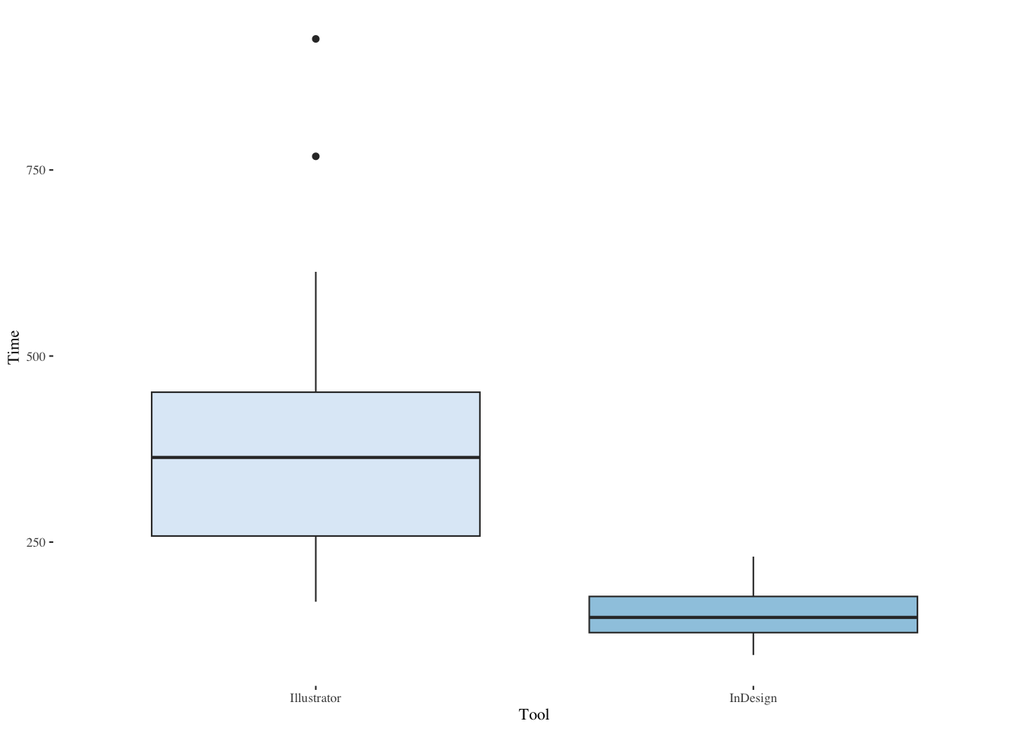

```r
ggplot(dt,aes(Tool,Time,fill=Tool)) +
  geom_boxplot(show.legend=FALSE) +
  scale_fill_brewer(palette="Blues") +
  theme_tufte(base_size=8)
```

Both the median and the variance is much larger for Illustrator than for InDesign.

Conduct a Shapiro-Wilk test for normality for each tool and comment.

```r
shapiro.test(dt[dt$Tool=="Illustrator",]$Time)
```

```
    Shapiro-Wilk normality test

data:  dt[dt$Tool == "Illustrator", ]$Time
W = 0.90521, p-value = 0.01129
```

```r
shapiro.test(dt[dt$Tool=="InDesign",]$Time)
```

```
    Shapiro-Wilk normality test

data:  dt[dt$Tool == "InDesign", ]$Time
W = 0.95675, p-value = 0.2553
```

In the case of InDesign, we fail to reject the null hypothesis that the data are drawn from a normal distribution. In the case of Illustrator, we reject the null hypothesis at the five percent level but not at the one percent level (just barely).

Conduct a Shapiro-Wilk test for normality on the residuals and comment.

```r
m<-aov(Time~Tool,data=dt)
shapiro.test(residuals(m))
```

```
    Shapiro-Wilk normality test

data:  residuals(m)
W = 0.85077, p-value = 3.211e-06
```

We reject the null hypothesis that the residuals are normally distributed.

Conduct a Brown-Forsythe test of homoscedasticity.

```r
leveneTest(Time~Tool,data=dt,center=median)
```

```
Levene's Test for Homogeneity of Variance (center = median)
      Df F value    Pr(>F)
group  1  20.082 3.545e-05 ***
      58
---
Signif. codes:  0 '***' 0.001 '**' 0.01 '*' 0.05 '.' 0.1 ' ' 1
```

We reject the null hypothesis that the two samples are drawn from populations with equal variance.

Fit a lognormal distribution to the Time response for each Tool. Conduct a Kolmogorov-Smirnov goodness-of-fit test and comment.

```r
fit<-fitdistr(dt[dt$Tool=="Illustrator",]$Time,
    "lognormal")$estimate
tst<-ks.test(dt[dt$Tool=="Illustrator",]$Time,
    "plnorm",meanlog=fit[1],sdlog=fit[2],exact=TRUE)
tst
```

```
    Exact one-sample Kolmogorov-Smirnov test

data:  dt[dt$Tool == "Illustrator", ]$Time
D = 0.093358, p-value = 0.9344
alternative hypothesis: two-sided
```

```r
fit<-fitdistr(dt[dt$Tool=="InDesign",]$Time,
    "lognormal")$estimate
tst<-ks.test(dt[dt$Tool=="InDesign",]$Time,
    "plnorm",meanlog=fit[1],sdlog=fit[2],exact=TRUE)
tst
```

```
    Exact one-sample Kolmogorov-Smirnov test

data:  dt[dt$Tool == "InDesign", ]$Time
D = 0.10005, p-value = 0.8958
alternative hypothesis: two-sided
```

We fail to reject the null hypothesis that the Illustrator sample is drawn from a lognormal distribution. We fail to reject the null hypothesis that the InDesign sample is drawn from a lognormal distribution.

Create a log-transformed Time response column. Compute the mean for each tool and comment.

```r
dt$logTime<-log(dt$Time)
mean(dt$logTime[dt$Tool=="Illustrator"])
```

```
[1] 5.894288
```

```r
mean(dt$logTime[dt$Tool=="InDesign"])
```

```
[1] 5.03047
```

```r
dt |>
  group_by(Tool) |>
  summarize(mean=mean(logTime),sd=sd(logTime))
```

```
      mean        sd
1 5.462379 0.5429946
```

The mean for Illustrator appears to be larger than the mean for InDesign.

Conduct an independent-samples $t$-test on the log-transformed Time response, using the Welch version for unequal variances and comment.

```r
t.test(logTime~Tool,data=dt,var.equal=FALSE)
```

```
    Welch Two Sample t-test

data:  logTime by Tool
t = 10.23, df = 43.293, p-value = 3.98e-13
alternative hypothesis: true difference in means between group Illustrator and group InDesign is not equal to 0
95 percent confidence interval:
 0.6935646 1.0340718
sample estimates:
mean in group Illustrator    mean in group InDesign
                 5.894288                  5.030470
```

We reject the null hypothesis that the true difference in means is equal to 0.

Conduct an exact nonparametric Mann-Whitney $U$ test on the Time response and comment.

```r
wilcox_test(Time~Tool,data=dt,distribution="exact")
```

```
    Exact Wilcoxon-Mann-Whitney Test

data:  Time by Tool (Illustrator, InDesign)
Z = 6.3425, p-value = 5.929e-14
alternative hypothesis: true mu is not equal to 0
```

We reject the null hypothesis that the samples were drawn from populations with the same distribution.

# Differences in writing speed among three tools (Three levels of a factor in ANOVA)

We’ll examine three levels of a factor, which is an alphabet system used for writing. The three levels are named for the text entry systems, EdgeWrite, Graffiti, and Unistrokes.

```r
alpha<-read_csv("alphabets.csv")
alpha$Subject<-as.factor(alpha$Subject)
alpha$Alphabet<-as.factor(alpha$Alphabet)
summary(alpha)
```

```
    Subject         Alphabet       WPM
 1      : 1   EdgeWrite :20   Min.   : 3.960
 2      : 1   Graffiti  :20   1st Qu.: 9.738
 3      : 1   Unistrokes:20   Median :13.795
 4      : 1                   Mean   :14.517
 5      : 1                   3rd Qu.:18.348
 6      : 1                   Max.   :28.350
 (Other):54
```

Plot the three text entry systems.

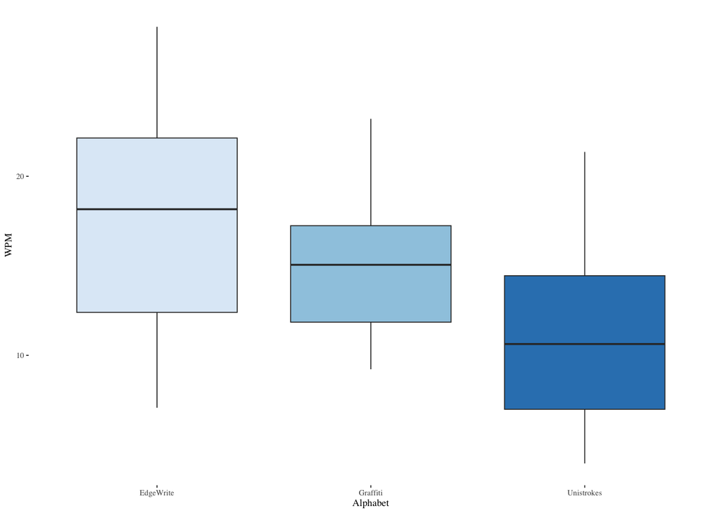

```r
ggplot(alpha,aes(Alphabet,WPM,fill=Alphabet)) +
  geom_boxplot(show.legend=FALSE) +
  scale_fill_brewer(palette="Blues") +
  theme_tufte(base_size=7)
```

Identify the average words per minute written with EdgeWrite.

```r
mean(alpha[alpha$Alphabet=="EdgeWrite",]$WPM)
```

```
[1] 17.14
```

Conduct a Shapiro-Wilk test for normality on each method.

```r
shapiro.test(alpha$WPM[alpha$Alphabet=="EdgeWrite"])
```

```
    Shapiro-Wilk normality test

data:  alpha$WPM[alpha$Alphabet == "EdgeWrite"]
W = 0.95958, p-value = 0.5355
```

```r
shapiro.test(alpha$WPM[alpha$Alphabet=="Graffiti"])
```

```
    Shapiro-Wilk normality test

data:  alpha$WPM[alpha$Alphabet == "Graffiti"]
W = 0.94311, p-value = 0.2743
```

```r
shapiro.test(alpha$WPM[alpha$Alphabet=="Unistrokes"])
```

```
    Shapiro-Wilk normality test

data:  alpha$WPM[alpha$Alphabet == "Unistrokes"]
W = 0.94042, p-value = 0.2442
```

Conduct a Shapiro-Wilk test for normality on the residuals of an ANOVA model stipulating that Alphabet affects WPM.

```r
m<-aov(WPM~Alphabet,data=alpha)
shapiro.test(residuals(m))
```

```
    Shapiro-Wilk normality test

data:  residuals(m)
W = 0.97762, p-value = 0.3363
```

Test for homoscedasticity.

```r
leveneTest(alpha$WPM~alpha$Alphabet,center="median")
```

```
Levene's Test for Homogeneity of Variance (center = "median")
      Df F value Pr(>F)
group  2  1.6219 0.2065
      57
```

Now test all three. The `mcp` function tests multiple means. The keyword `Tukey` means to do all the possible pairwise comparisons of Alphabet, i.e., Graffiti and EdgeWrite, Graffiti and Unistrokes, and EdgeWrite and Unistrokes. `m` is the oneway ANOVA model we created above.

```r
summary(multcomp::glht(m,multcomp::mcp(Alphabet="Tukey")),test=adjusted(type="holm"))
```

```
     Simultaneous Tests for General Linear Hypotheses

Multiple Comparisons of Means: Tukey Contrasts


Fit: aov(formula = WPM ~ Alphabet, data = alpha)

Linear Hypotheses:
                            Estimate Std. Error t value Pr(>|t|)
Graffiti - EdgeWrite == 0     -2.100      1.693  -1.241  0.21982
Unistrokes - EdgeWrite == 0   -5.769      1.693  -3.407  0.00363 **
Unistrokes - Graffiti == 0    -3.668      1.693  -2.166  0.06894 .
---
Signif. codes:  0 '***' 0.001 '**' 0.01 '*' 0.05 '.' 0.1 ' ' 1
(Adjusted p values reported -- holm method)
```

Conduct a nonparametric oneway ANOVA using the Kruskal-Wallis test to see if the samples have the same distribution. The null hypothesis is that the samples come from the same distribution.

```r
kruskal_test(alpha$WPM~alpha$Alphabet,distribution="asymptotic")
```

```
    Asymptotic Kruskal-Wallis Test

data:  alpha$WPM by
     alpha$Alphabet (EdgeWrite, Graffiti, Unistrokes)
chi-squared = 9.7019, df = 2, p-value = 0.007821
```

Conduct manual post hoc Mann-Whitney pairwise comparisons and adjust the $p$-values to take into account the possibility of false discovery.

```r
ewgf<-wilcox.test(alpha$WPM[alpha$Alphabet=="EdgeWrite"],alpha$WPM[alpha$Alphabet=="Graffiti"],paired=FALSE,exact=FALSE)
ewun<-wilcox.test(alpha$WPM[alpha$Alphabet=="EdgeWrite"],alpha$WPM[alpha$Alphabet=="Unistrokes"],paired=FALSE,exact=FALSE)
gfun<-wilcox.test(alpha$WPM[alpha$Alphabet=="Graffiti"],alpha$WPM[alpha$Alphabet=="Unistrokes"],paired=FALSE,exact=FALSE)
p.adjust(c(ewgf$p.value,ewun$p.value,gfun$p.value),method="holm")
```

```
[1] 0.20358147 0.01810677 0.04146919
```

# Same person using two different tools (Paired samples $t$-test)

Is it better to search or scroll for contacts in a smartphone contacts manager? Which takes more time? Which takes more effort? Which is more error-prone? Start by reading in data, converting to factors, and summarizing.

```r
srchscrl <- read_csv("srchscrl.csv")
srchscrl$Subject <- factor(srchscrl$Subject)
srchscrl$Order   <- factor(srchscrl$Order)
srchscrl$Technique   <- factor(srchscrl$Technique)
#. srchscrl$Errors   <- factor(srchscrl$Errors,ordered=TRUE,levels=c(0,1,2,3,4))
summary(srchscrl)
```

```
    Subject    Technique  Order       Time           Errors         Effort
 1      : 2   Scroll:20   1:20   Min.   : 49.0   Min.   :0.00   Min.   :1
 2      : 2   Search:20   2:20   1st Qu.: 94.5   1st Qu.:0.75   1st Qu.:3
 3      : 2                      Median :112.5   Median :1.50   Median :4
 4      : 2                      Mean   :117.0   Mean   :1.60   Mean   :4
 5      : 2                      3rd Qu.:148.2   3rd Qu.:2.25   3rd Qu.:5
 6      : 2                      Max.   :192.0   Max.   :4.00   Max.   :7
 (Other):28
```

```r
pacman::p_load(xtable)
options(xtable.comment=FALSE)
options(xtable.booktabs=TRUE)
xtable(head(srchscrl),caption="First rows of data")
```

View descriptive statistics by Technique. There are several ways to do this. The following uses the `plyr` package.

```r
plyr::ddply(srchscrl, ~ Technique,
      function(data) summary(data$Time))
```

```
  Technique Min. 1st Qu. Median  Mean 3rd Qu. Max.
1    Scroll   49  123.50  148.5 137.2     161  192
2    Search   50   86.75   99.5  96.8     106  147
```

```r
plyr::ddply(srchscrl, ~ Technique,
      summarise, Time.mean=mean(Time), Time.sd=sd(Time))
```

```
  Technique Time.mean  Time.sd
1    Scroll     137.2 35.80885
2    Search      96.8 23.23020
```

Another approach is to use the `dplyr` package. Be aware that it conflicts with `plyr` so you should try to avoid using both. If you must use both, as I did above, it may make the most sense to call particular functions from the `plyr` package rather than load the package. This is what I did with `plyr::ddply()` above.

```r
srchscrl |>
  group_by(Technique) |>
  summarize(mean=mean(Time),sd=sd(Time))
```

```
  mean       sd
1  117 36.14004
```

You can explore the Time response by making histograms or boxplots. One approach is to use the `ggplot2` package and put the histograms together in one frame. The `ggplot2` package allows for a remarkable variety of options.

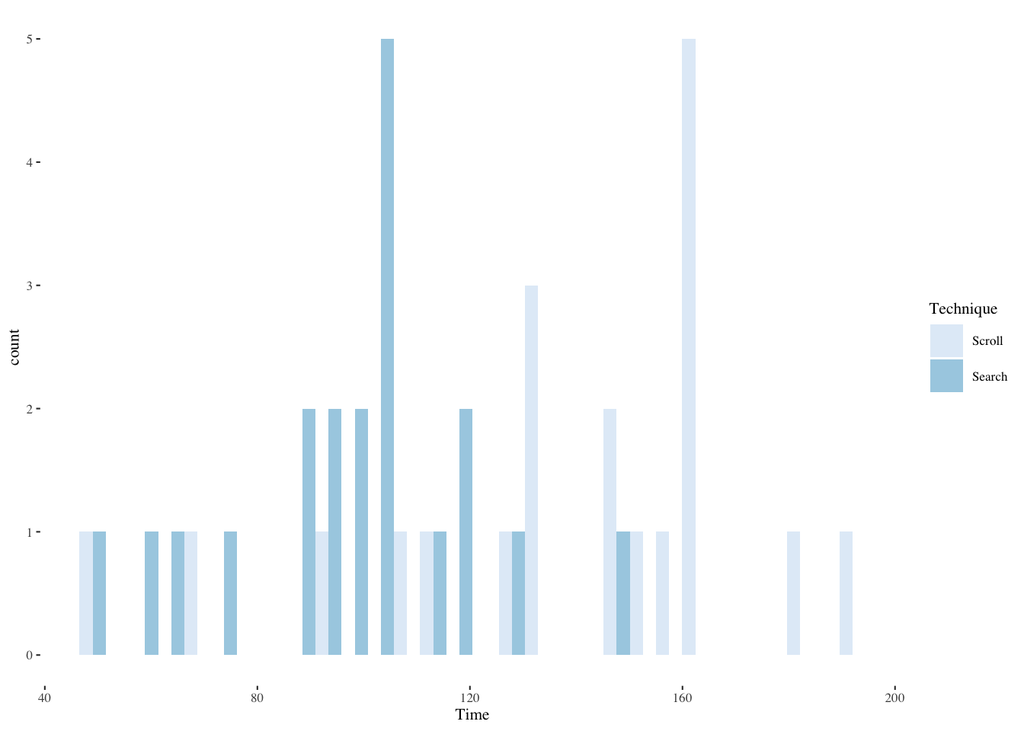

```r
ggplot(srchscrl,aes(Time,fill=Technique)) +
  geom_histogram(bins=30,alpha=0.9,position=position_dodge()) +
  scale_fill_brewer(palette="Blues") +
  theme_tufte(base_size=8)
```

We can use the same package for boxplots. Boxplots show the median as a bold line in the middle of the box. The box itself ranges from the first quartile (starting at the 25th percentile) to the third quartile (terminating at the 75th percentile). The whiskers run from the minimum to the maximum, where these are defined as the 25th percentile minus 1.5 times the interquartile range and the 75th percentile plus 1.5 times the interquartile range. The interquartile range is the width of the box. Dots outside the whiskers show outliers.

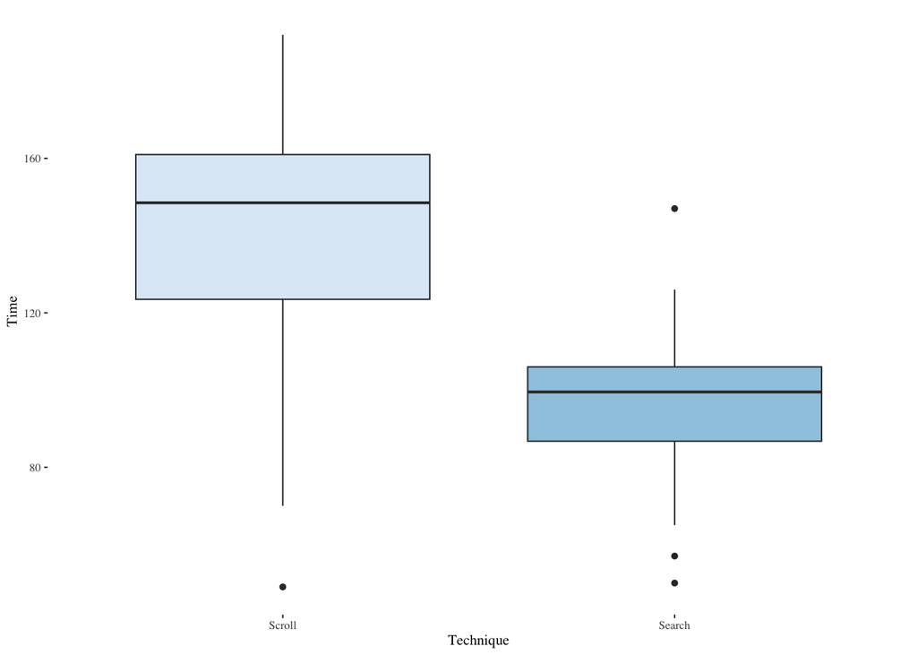

```r
ggplot(srchscrl,aes(Technique,Time,fill=Technique)) +
  geom_boxplot(show.legend=FALSE) +
  scale_fill_brewer(palette="Blues") +
  theme_tufte(base_size=8)
```

We would rather use parametric statistics if ANOVA assumptions are met. Recall that we can test for normality, normality of residuals, and homoscedasticity. In the case of a within-subjects experiment, we can also test for order effects which is one way to test the independence assumption. First test whether these times seem to be drawn from a normal distribution.

```r
shapiro.test(srchscrl[srchscrl$Technique == "Search",]$Time)
```

```
    Shapiro-Wilk normality test

data:  srchscrl[srchscrl$Technique == "Search", ]$Time
W = 0.96858, p-value = 0.7247
```

```r
shapiro.test(srchscrl[srchscrl$Technique == "Scroll",]$Time)
```

```
    Shapiro-Wilk normality test

data:  srchscrl[srchscrl$Technique == "Scroll", ]$Time
W = 0.91836, p-value = 0.09213
```

In both cases we fail to reject the null hypothesis, which is that the Time data are drawn from a normal distribution. Note that we fail to reject at $\alpha=0.05$ but that in the case of the Scroll technique we would reject at $\alpha=0.1$.

Fit a model for testing residuals—the Error function is used to indicate within-subject effects, i.e., each Subject was exposed to all levels of Technique. generally, Error(S/(A*B*C)) means each S was exposed to every level of A, B, C and S is a column encoding subject ids.

```r
m <- aov(Time ~ Technique + Error(Subject/Technique),
    data=srchscrl)
```

The above-specified model has residuals—departures of the observed data from the data that would be expected if the model were accurate.

Now we can test the residuals of this model for normality and also examine a QQ plot for normality. The QQ plot shows the theoretical line to which the residuals should adhere if they are normally distributed. Deviations from that line are indications of non-normality. First test by Subject.

```r
shapiro.test(residuals(m$Subject))
```

```
    Shapiro-Wilk normality test

data:  residuals(m$Subject)
W = 0.9603, p-value = 0.5783
```

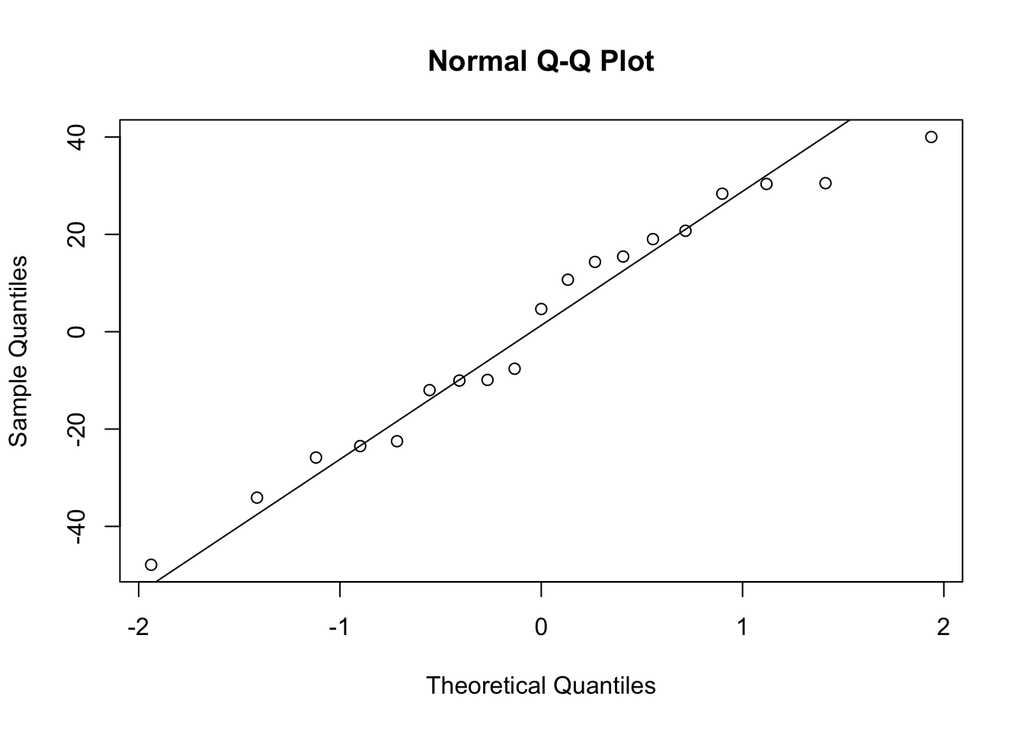

```r
qqnorm(residuals(m$Subject))
qqline(residuals(m$Subject))
```

We fail to reject the null hypothesis of normality and the QQ plot looks normal. So far, so good.

Next test by Subject:Technique.

```r
shapiro.test(residuals(m$'Subject:Technique'))
```

```
    Shapiro-Wilk normality test

data:  residuals(m$"Subject:Technique")
W = 0.97303, p-value = 0.8172
```

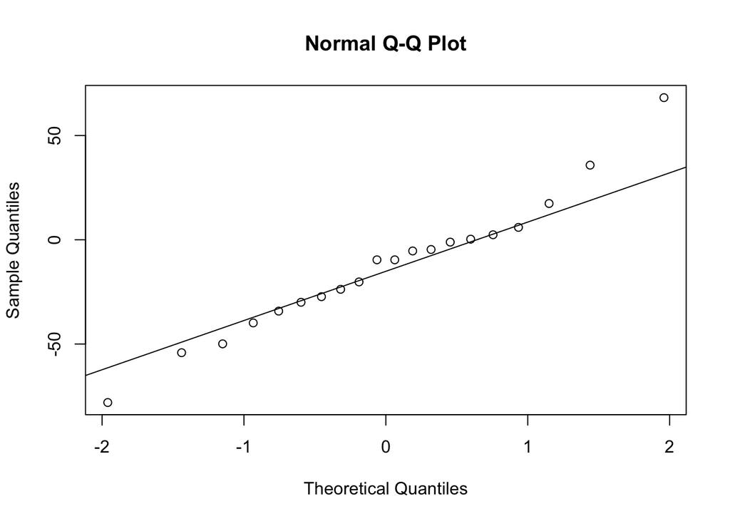

```r
qqnorm(residuals(m$'Subject:Technique'))
qqline(residuals(m$'Subject:Technique'))
```

We fail to reject the null hypothesis of normality and the QQ plot looks normal. We’re getting there.

We’re still checking the ANOVA assumptions. Next thing to test is homoscedasticity, the assumption of equal variance. For this we use the Brown-Forsythe test, a variant of Levene’s test that uses the median instead of the mean, providing greater robustness against non-normal data.

```r
leveneTest(Time ~ Technique, data=srchscrl, center=median)
```

```
Levene's Test for Homogeneity of Variance (center = median)
      Df F value Pr(>F)
group  1  2.0088 0.1645
      38
```

This experiment used counterbalancing to ward off the possibility of an order effect. An order effect results from learning or fatigue or some other factor based on the order in which the tests were run. We would like to not have that happen and one solution is to have half the subjects do task A first and half the subjects do task B first. This is the simplest form of counterbalancing. It becomes more problematic if there are more than two tasks.

For a paired-samples $t$-test we must use a wide-format table; most R functions do not require a wide-format table, but the `dcast()` function offers a quick way to translate long-format into wide-format when we need it.

A wide-format table has one subject in every row. A long-format table has one observation in every row. Most R functions use long-format tables.

```r
pacman::p_load(reshape2)
srchscrl.wide.order <- dcast(srchscrl, Subject ~ Order,
                 value.var="Time")
```

```r
xtable(head(srchscrl.wide.order),
       caption="First rows of wide order")
```

Now conduct a $t$-test to see if order has an effect.

```r
t.test(srchscrl.wide.order$"1", srchscrl.wide.order$"2",
       paired=TRUE, var.equal=TRUE)
```

```
    Paired t-test

data:  srchscrl.wide.order$"1" and srchscrl.wide.order$"2"
t = -1.3304, df = 19, p-value = 0.1991
alternative hypothesis: true mean difference is not equal to 0
95 percent confidence interval:
 -47.34704  10.54704
sample estimates:
mean difference
          -18.4
```

We fail to reject the null hypothesis that the responses do not differ according to order. To phrase this in a more readable (!) way, we have evidence that the order does not matter.

## Running the paired $t$-test

It now makes sense to use a paired $t$-test since the ANOVA assumptions have been satisfied. This is a parametric test of Time where we pair subjects by technique. Again, we need the wide-format table to conduct a paired test. The wide-format table has one row for each subject rather than one row for each observation.

```r
srchscrl.wide.tech = dcast(srchscrl, Subject ~ Technique,
               value.var="Time")
```

```r
xtable(head(srchscrl.wide.tech),
       caption="First rows of wide technique")
```

```r
t.test(srchscrl.wide.tech$Search, srchscrl.wide.tech$Scroll,
       paired=TRUE, var.equal=TRUE)
```

```
    Paired t-test

data:  srchscrl.wide.tech$Search and srchscrl.wide.tech$Scroll
t = -3.6399, df = 19, p-value = 0.001743
alternative hypothesis: true mean difference is not equal to 0
95 percent confidence interval:
 -63.63083 -17.16917
sample estimates:
mean difference
          -40.4
```

This supports the intuition we developed doing the histogram and boxplots only now we have a valid statistical test to support this intuition.

Suppose we did not satisfy the ANOVA assumptions. Then we would conduct the nonparametric equivalent of paired-samples t-test.

## Exploring a Poisson-distributed factor

Explore the Errors response; error counts are often Poisson-distributed.

```r
plyr::ddply(srchscrl, ~ Technique, function(data)
      summary(data$Errors))
```

```
  Technique Min. 1st Qu. Median Mean 3rd Qu. Max.
1    Scroll    0       0    0.5  0.7       1    2
2    Search    1       2    2.5  2.5       3    4
```

```r
plyr::ddply(srchscrl, ~ Technique, summarise,
      Errors.mean=mean(Errors), Errors.sd=sd(Errors))
```

```
  Technique Errors.mean Errors.sd
1    Scroll         0.7 0.8013147
2    Search         2.5 1.0513150
```

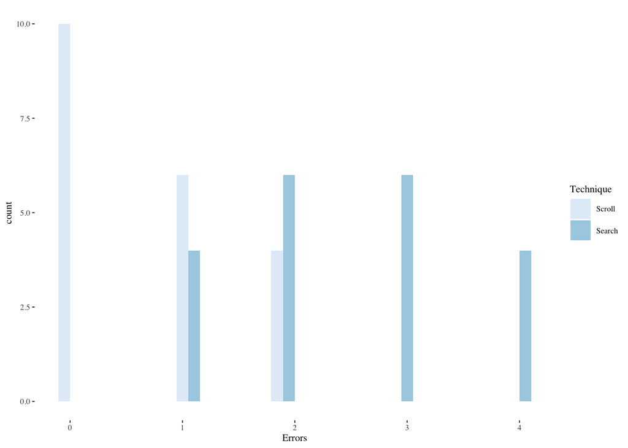

```r
ggplot(srchscrl,aes(Errors,fill=Technique)) +
  geom_histogram(bins=20,alpha=0.9,position=position_dodge()) +
  scale_fill_brewer(palette="Blues") +
  theme_tufte(base_size=8)
```

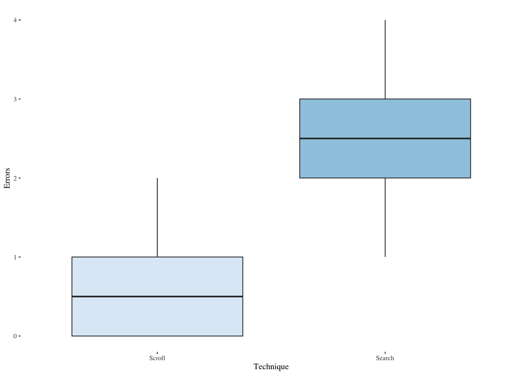

```r
ggplot(srchscrl,aes(Technique,Errors,fill=Technique)) +
  geom_boxplot(show.legend=FALSE) +
  scale_fill_brewer(palette="Blues") +
  theme_tufte(base_size=8)
```

Try to fit a Poisson distribution for count data. Note that `ks.test()` only works for continuous distributions, but Poisson distributions are discrete, so use fitdist, not fitdistr, and test with gofstat.

```r
pacman::p_load(fitdistrplus)
fit = fitdist(srchscrl[srchscrl$Technique == "Search",]$Errors,
          "pois", discrete=TRUE)
gofstat(fit) # goodness-of-fit test
```

```
Chi-squared statistic:  1.522231
Degree of freedom of the Chi-squared distribution:  2
Chi-squared p-value:  0.4671449
   the p-value may be wrong with some theoretical counts < 5
Chi-squared table:
     obscounts theocounts
<= 1  4.000000   5.745950
<= 2  6.000000   5.130312
<= 3  6.000000   4.275260
> 3   4.000000   4.848477

Goodness-of-fit criteria
                               1-mle-pois
Akaike's Information Criterion   65.61424
Bayesian Information Criterion   66.60997
```

```r
fit = fitdist(srchscrl[srchscrl$Technique == "Scroll",]$Errors,
          "pois", discrete=TRUE)
gofstat(fit) # goodness-of-fit test
```

```
Chi-squared statistic:  0.3816087
Degree of freedom of the Chi-squared distribution:  1
Chi-squared p-value:  0.5367435
   the p-value may be wrong with some theoretical counts < 5
Chi-squared table:
     obscounts theocounts
<= 0 10.000000   9.931706
<= 1  6.000000   6.952194
> 1   4.000000   3.116100

Goodness-of-fit criteria
                               1-mle-pois
Akaike's Information Criterion   45.53208
Bayesian Information Criterion   46.52781
```

Conduct a Wilcoxon signed-rank test on Errors.

```r
wilcoxsign_test(Errors ~ Technique | Subject,
        data=srchscrl, distribution="exact")
```

```
    Exact Wilcoxon-Pratt Signed-Rank Test

data:  y by x (pos, neg)
     stratified by block
Z = -3.6701, p-value = 6.104e-05
alternative hypothesis: true mu is not equal to 0
```

Note: the term afer the “|” indicates the within-subjects blocking term for matched pairs.

## Examining a Likert scale response item

Now also examine Effort, the ordinal Likert scale response (1-7).

```r
plyr::ddply(srchscrl, ~ Technique, function(data)
      summary(data$Effort))
```

```
  Technique Min. 1st Qu. Median Mean 3rd Qu. Max.
1    Scroll    1       3      4  4.4    6.00    7
2    Search    1       3      4  3.6    4.25    5
```

```r
plyr::ddply(srchscrl, ~ Technique, summarise,
      Effort.mean=mean(Effort), Effort.sd=sd(Effort))
```

```
  Technique Effort.mean Effort.sd
1    Scroll         4.4  1.698296
2    Search         3.6  1.187656
```

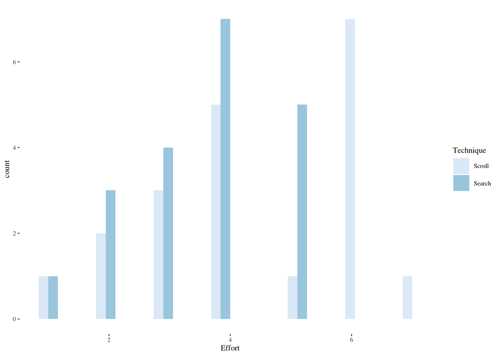

```r
ggplot(srchscrl,aes(Effort,fill=Technique)) +
  geom_histogram(bins=20,alpha=0.9,position=position_dodge()) +
  scale_fill_brewer(palette="Blues") +
  theme_tufte(base_size=8)
```

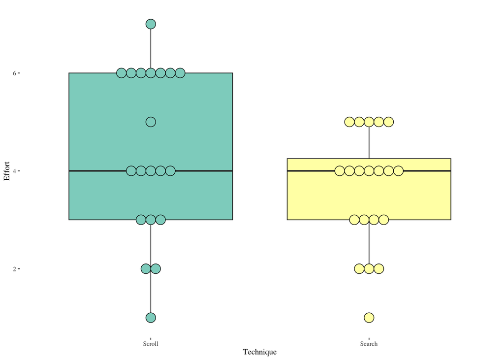

```r
ggplot(srchscrl,aes(Technique,Effort,fill=Technique)) +
  geom_boxplot(show.legend=FALSE) +
  scale_fill_brewer(palette="Set3") +
  geom_dotplot(show.legend=FALSE,binaxis='y',stackdir='center',dotsize=1) +
  theme_tufte(base_size=8)
```

Our response is ordinal within-subjects, so use nonparametric Wilcoxon signed-rank.

```r
wilcoxsign_test(Effort ~ Technique | Subject,
        data=srchscrl, distribution="exact")
```

```
    Exact Wilcoxon-Pratt Signed-Rank Test

data:  y by x (pos, neg)
     stratified by block
Z = 1.746, p-value = 0.08746
alternative hypothesis: true mu is not equal to 0
```

# People doing tasks on different phones in different postures (Factorial ANOVA)

The scenario is text entry on smartphone keyboards: iPhone and Galaxy, in different postures: sitting, walking, standing.

The statistics employed include Factorial ANOVA, repeated measures ANOVA, main effects, interaction effects, the Aligned Rank Transform for nonparametric ANOVAs.

This is a $3 \times 2$ mixed factorial design. It is mixed in the sense that there is a between-subjects factor (Keyboard) and a within-subjects factor (Posture). It is balanced in the sense that there are twelve persons using each Keyboard and they are each examined for all three levels of Posture.

## Read and describe the data

```r
mbltxt <- read_csv("mbltxt.csv")
head(mbltxt)
```

```
# A tibble: 6 × 6
  Subject Keyboard Posture Posture_Order   WPM Error_Rate
    <dbl> <chr>    <chr>           <dbl> <dbl>      <dbl>
1       1 iPhone   Sit                 1  20.2     0.022
2       1 iPhone   Stand               2  23.7     0.03
3       1 iPhone   Walk                3  20.8     0.0415
4       2 iPhone   Sit                 1  20.9     0.022
5       2 iPhone   Stand               3  23.3     0.0255
6       2 iPhone   Walk                2  19.1     0.0355
```

```r
mbltxt <- within(mbltxt, Subject <- as.factor(Subject))
mbltxt <- within(mbltxt, Keyboard <- as.factor(Keyboard))
mbltxt <- within(mbltxt, Posture <- as.factor(Posture))
mbltxt <- within(mbltxt, Posture_Order <- as.factor(Posture_Order))
summary(mbltxt)
```

```
    Subject     Keyboard   Posture   Posture_Order      WPM
 1      : 3   Galaxy:36   Sit  :24   1:24          Min.   : 9.454
 2      : 3   iPhone:36   Stand:24   2:24          1st Qu.:19.091
 3      : 3               Walk :24   3:24          Median :21.032
 4      : 3                                        Mean   :20.213
 5      : 3                                        3rd Qu.:23.476
 6      : 3                                        Max.   :25.380
 (Other):54
   Error_Rate
 Min.   :0.01500
 1st Qu.:0.02200
 Median :0.03050
 Mean   :0.03381
 3rd Qu.:0.04000
 Max.   :0.06950
```

## Explore the WPM (words per minute) data

```r
s <- mbltxt |>
  group_by(Keyboard,Posture) |>
  summarize(
    WPM.median=median(WPM),
    WPM.mean=mean(WPM),
    WPM.sd=sd(WPM)
  )
s
```

```
  WPM.median WPM.mean  WPM.sd
1    21.0325 20.21251 4.13684
```

## Histograms for both factors

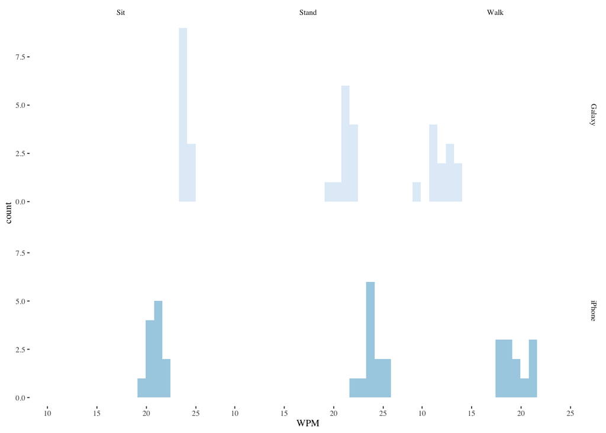

```r
ggplot(mbltxt,aes(WPM,fill=Keyboard)) +
  geom_histogram(bins=20,alpha=0.9,position="dodge",show.legend=FALSE) +
  scale_color_brewer() +
  scale_fill_brewer() +
  facet_grid(Keyboard~Posture) +
  theme_tufte(base_size=8)
```

## Boxplot of both factors

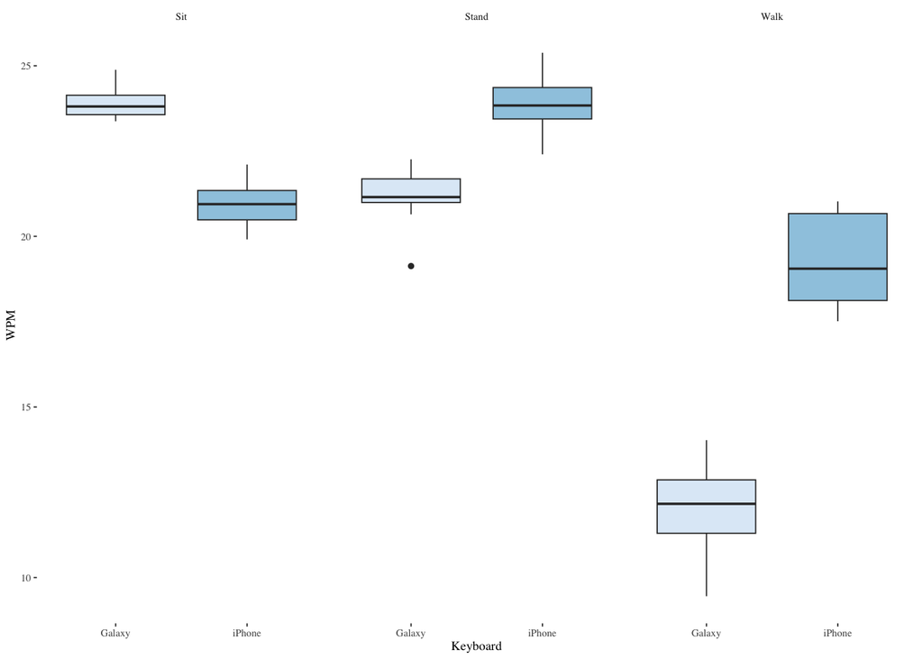

```r
ggplot(mbltxt,aes(Keyboard,WPM,fill=Keyboard)) +
  geom_boxplot(show.legend=FALSE) +
  scale_fill_brewer(palette="Blues") +
  facet_wrap(~Posture) +
  theme_tufte(base_size=7)
```

## An interaction plot

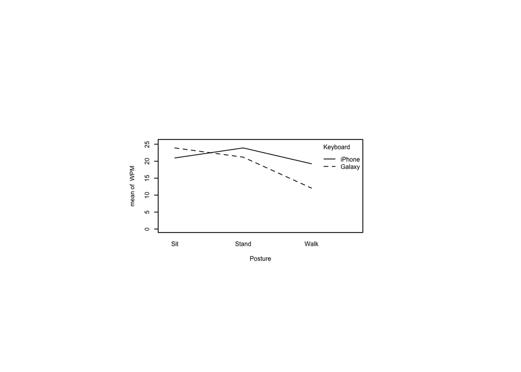

```r
par(pin=c(2.75,1.25),cex=0.5)
with(mbltxt,
     interaction.plot(Posture, Keyboard, WPM,
                      ylim=c(0, max(mbltxt$WPM))))
```

## Test for a Posture order effect

This is to ensure that counterbalancing worked.

```r
pacman::p_load(ez)
m <- ezANOVA(dv=WPM,
            between=Keyboard,
            within=Posture_Order,
            wid=Subject,
            data=mbltxt)
m$Mauchly
```

```
                  Effect         W         p p<.05
3          Posture_Order 0.9912922 0.9122583
4 Keyboard:Posture_Order 0.9912922 0.9122583
```

Wikipedia tells us that “Sphericity is an important assumption of a repeated-measures ANOVA. It refers to the condition where the variances of the differences between all possible pairs of within-subject conditions (i.e., levels of the independent variable) are equal. The violation of sphericity occurs when it is not the case that the variances of the differences between all combinations of the conditions are equal. If sphericity is violated, then the variance calculations may be distorted, which would result in an $F$-ratio that would be inflated.” (from the Wikipedia article on Mauchly’s sphericity test)

Mauchly’s test of sphericity above tells us that there is *not* a significant departure from sphericity, so we can better rely on the $F$-statistic in the following ANOVA, the purpose of which is to detect any order effect that would interfere with our later results.

```r
m$ANOVA
```

```
                  Effect DFn DFd            F            p p<.05          ges
2               Keyboard   1  22 1.244151e+02 1.596641e-10     * 0.0794723123
3          Posture_Order   2  44 5.166254e-02 9.497068e-01       0.0023071128
4 Keyboard:Posture_Order   2  44 2.830819e-03 9.971734e-01       0.0001266932
```

The $F$-statistic for Posture_Order is very small, indicating that there is not an order effect. That gives us the confidence to run the ANOVA test we wanted to run all along.

# Differences between people’s performance and within a person’s performance (Two-way mixed factorial ANOVA)

Since a mixed factorial design by definition has both a between-subjects and a within-subjects factor, we don’t need to also mention that this is a repeated measures test.

```r
m <- ezANOVA(dv=WPM,
            between=Keyboard,
            within=Posture,
            wid=Subject,
            data=mbltxt)
m$Mauchly
```

```
            Effect         W           p p<.05
3          Posture 0.6370236 0.008782794     *
4 Keyboard:Posture 0.6370236 0.008782794     *
```

In this case, sphericity *is* violated, so we need to additionally apply the Greenhouse-Geisser correction or the less conservative Huyn-Feldt correction. Nevertheless, let’s look at the uncorrected ANOVA table. Later, we’ll compare it with the uncorrected version provided by the `aov()` function.

```r
m$ANOVA
```

```
            Effect DFn DFd        F            p p<.05       ges
2         Keyboard   1  22 124.4151 1.596641e-10     * 0.6151917
3          Posture   2  44 381.4980 1.602465e-28     * 0.9255880
4 Keyboard:Posture   2  44 157.1600 9.162076e-21     * 0.8367128
```

Note that “ges” in the ANOVA table is the generalized eta-squared measure of effect size, $\eta^2_G$, preferred to eta-squared or partial eta-squared. See Roger Bakeman (2005) “Recommended effect size statistics for repeated measures designs”, *Behavior Research Methods*, 37 (3) pages 379–384. There, he points out that the usual $\eta^2$ is the ratio of effect to total variance:

$$\eta^2=\frac{SS_{\text{effect}}}{SS_{\text{total}}}$$

where $SS$ is sum of squares. This is similar to the $R^2$ measure typically reported for regression results. The generalized version is alleged to compensate for the deficiencies that $\eta^2$ shares with $R^2$, mainly that it can be improved by simply adding more predictors. The generalized version looks like this:

$$\eta^2_G=\frac{SS_{\text{effect}}}{\delta \times SS_{\text{effect}} + \sum SS_{\text{measured}}}$$

Here $\delta=0$ if the effect involves one or more measured factors and $\delta=1$ if the effect involves only manipulated factors. (Actually it is a little more complicated—here I’m just trying to convey a crude idea that $\eta^2_G$ ranges between 0 and 1 and that, as it approaches 1, the size of the effect is greater. Oddly enough, it is common to report effect sizes as simply small, medium, or large.)

Now compute the corrected degrees of freedom for each corrected effect.

```r
pos <- match(m$'Sphericity Corrections'$Effect,
            m$ANOVA$Effect) # positions of within-Ss efx in m$ANOVA
m$Sphericity$GGe.DFn <- m$Sphericity$GGe * m$ANOVA$DFn[pos] # Greenhouse-Geisser
m$Sphericity$GGe.DFd <- m$Sphericity$GGe * m$ANOVA$DFd[pos]
m$Sphericity$HFe.DFn <- m$Sphericity$HFe * m$ANOVA$DFn[pos] # Huynh-Feldt
m$Sphericity$HFe.DFd <- m$Sphericity$HFe * m$ANOVA$DFd[pos]
m$Sphericity
```

```
            Effect       GGe        p[GG] p[GG]<.05       HFe        p[HF]
3          Posture 0.7336884 1.558280e-21         * 0.7731517 1.432947e-22
4 Keyboard:Posture 0.7336884 7.800756e-16         * 0.7731517 1.447657e-16
  p[HF]<.05  GGe.DFn  GGe.DFd  HFe.DFn  HFe.DFd
3         * 1.467377 32.28229 1.546303 34.01868
4         * 1.467377 32.28229 1.546303 34.01868
```

The above table shows the Greenhouse Geisser correction to the numerator (GGe.DFn) and denominator (GGe.DFd) degrees of freedom and the resulting $p$-values (p[GG]). The Greenhouse Geiser epsilon statistic ($\epsilon$) is shown as GGe. There is an analogous set of measures for the less conservative Huynh-Feldt correction. Note that you could calculate a more conservative $F$-statistic using the degrees of freedom given even though a corrected $F$-statistic is not shown for some reason.

## ANOVA results from `aov()`

The uncorrected results from the `ez` package are the same as the `aov()` function in base R, shown below.

```r
m <- aov(WPM ~ Keyboard * Posture + Error(Subject/Posture),
        data=mbltxt) # fit model
summary(m)
```

```
Error: Subject
          Df Sum Sq Mean Sq F value  Pr(>F)
Keyboard   1  96.35   96.35   124.4 1.6e-10 ***
Residuals 22  17.04    0.77
---
Signif. codes:  0 '***' 0.001 '**' 0.01 '*' 0.05 '.' 0.1 ' ' 1

Error: Subject:Posture
                 Df Sum Sq Mean Sq F value Pr(>F)
Posture           2  749.6   374.8   381.5 <2e-16 ***
Keyboard:Posture  2  308.8   154.4   157.2 <2e-16 ***
Residuals        44   43.2     1.0
---
Signif. codes:  0 '***' 0.001 '**' 0.01 '*' 0.05 '.' 0.1 ' ' 1
```

## Manual post hoc pairwise comparisons

Because the ANOVA table showed a significant interaction effect and the significance of that interaction effect was borne out by the small p[GG] value, it makes sense to conduct post hoc pairwise comparisons. These require reshaping the data to a wide format because the $t$ test expects data in that format.

```r
mbltxt.wide <- dcast(mbltxt, Subject + Keyboard ~ Posture,
                    value.var="WPM")
head(mbltxt.wide)
```

```
  Subject Keyboard     Sit   Stand    Walk
1       1   iPhone 20.2145 23.7485 20.7960
2       2   iPhone 20.8805 23.2595 19.1305
3       3   iPhone 21.2635 23.4945 20.8545
4       4   iPhone 20.7080 23.9220 18.2575
5       5   iPhone 21.0075 23.4700 17.7105
6       6   iPhone 19.9115 24.2975 19.8550
```

```r
sit <- t.test(mbltxt.wide$Sit ~ Keyboard, data=mbltxt.wide)
std <- t.test(mbltxt.wide$Stand ~ Keyboard, data=mbltxt.wide)
wlk <- t.test(mbltxt.wide$Walk ~ Keyboard, data=mbltxt.wide)
p.adjust(c(sit$p.value, std$p.value, wlk$p.value), method="holm")
```

```
[1] 3.842490e-10 4.622384e-08 1.450214e-11
```

The above $p$-values indicate significant differences for all three.

## Compare iPhone ‘sit’ and ‘walk’

```r
par(pin=c(2.75,1.25),cex=0.5)
tst<-t.test(mbltxt.wide[mbltxt.wide$Keyboard == "iPhone",]$Sit,
       mbltxt.wide[mbltxt.wide$Keyboard == "iPhone",]$Walk,
       paired=TRUE)
tst
```

```
    Paired t-test

data:  mbltxt.wide[mbltxt.wide$Keyboard == "iPhone", ]$Sit and mbltxt.wide[mbltxt.wide$Keyboard == "iPhone", ]$Walk
t = 3.6259, df = 11, p-value = 0.003985
alternative hypothesis: true mean difference is not equal to 0
95 percent confidence interval:
 0.6772808 2.7695525
sample estimates:
mean difference
       1.723417
```

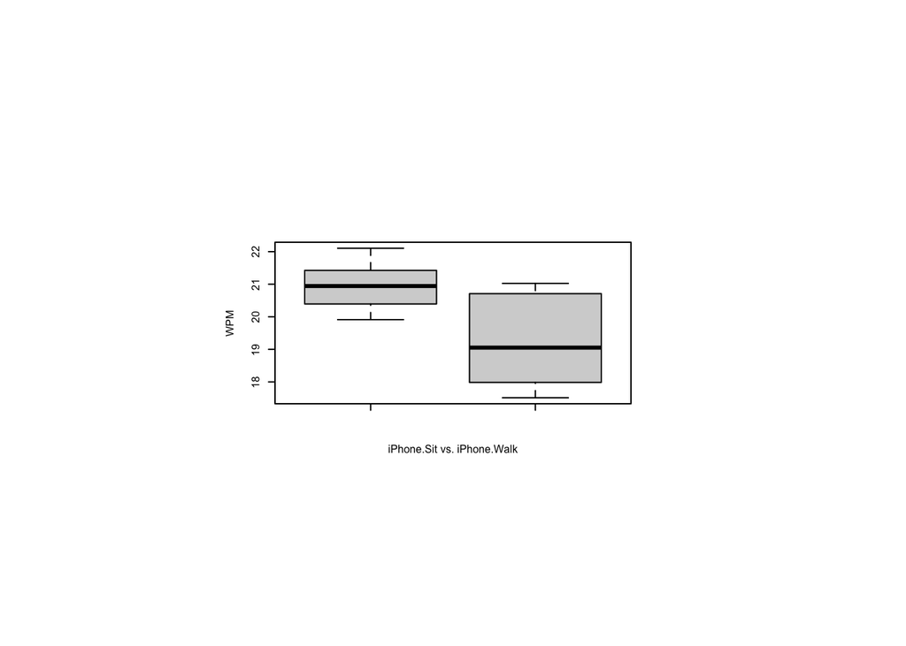

```r
par(pin=c(2.75,1.25),cex=0.5)
boxplot(mbltxt.wide[mbltxt.wide$Keyboard == "iPhone",]$Sit,
        mbltxt.wide[mbltxt.wide$Keyboard == "iPhone",]$Walk,
        xlab="iPhone.Sit vs. iPhone.Walk", ylab="WPM")
```

# What if ANOVA assumptions aren’t met? (Nonparametric approach to factorial ANOVA)

The rest of this section concerns a nonparametric approach developed at the University of Washington.

## The Aligned Rank Transform (ART) procedure

http://depts.washington.edu/aimgroup/proj/art/

## Explore the Error_Rate data

```r
s <- mbltxt |>
  group_by(Keyboard,Posture) |>
  summarize(
    WPM.median=median(Error_Rate),
    WPM.mean=mean(Error_Rate),
    WPM.sd=sd(Error_Rate)
  )
s
```

```
  WPM.median  WPM.mean    WPM.sd
1     0.0305 0.0338125 0.0154141
```

## Histograms of Error_Rate

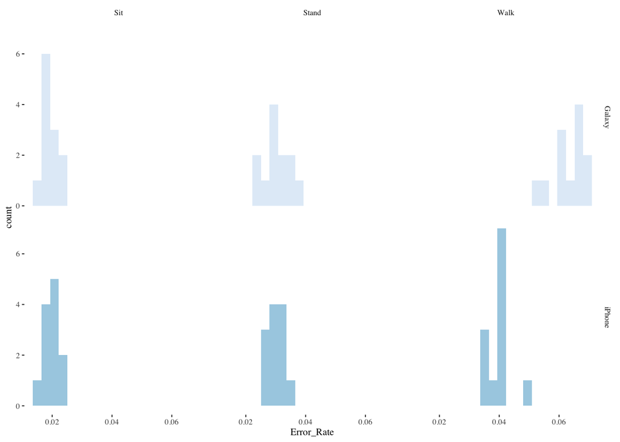

```r
ggplot(mbltxt,aes(Error_Rate,fill=Keyboard)) +
  geom_histogram(bins=20,alpha=0.9,position="dodge",show.legend=FALSE) +
  scale_color_brewer() +
  scale_fill_brewer() +
  facet_grid(Keyboard~Posture) +
  theme_tufte(base_size=8)
```

## Box plots of Error_Rate

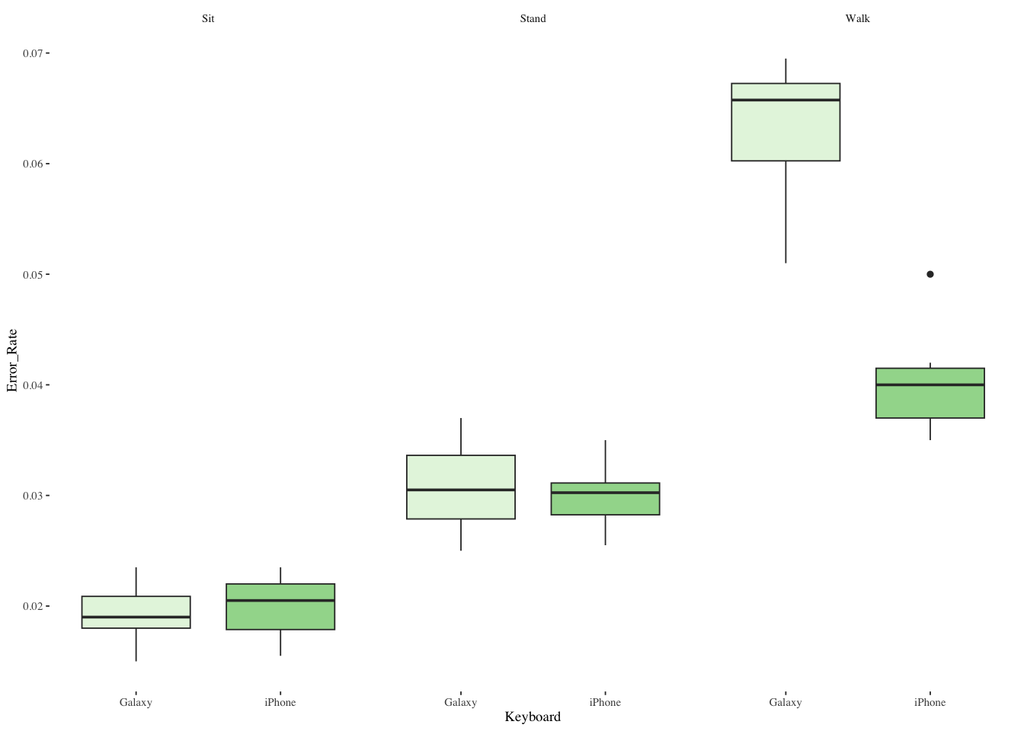

```r
ggplot(mbltxt,aes(Keyboard,Error_Rate,fill=Keyboard)) +
  geom_boxplot(show.legend=FALSE) +
  scale_fill_brewer(palette="Greens") +
  facet_wrap(~Posture) +
  theme_tufte(base_size=7)
```